# DGS_S1_codebook

Qilin Zhang

2023-03-31

```r
library(summarytools)
library(tidyverse) #data wrangling
library(codebook) #codebook generation
library(future) #reliability
library(ufs) #reliability
library(GGally) #reliability
library(GPArotation) #reliability
library(rio) #reading in different file types
library(labelled) #labeling data
```

## Cleaning

```r
metadata(data)$name <- "A short name for the data"
metadata(data)$description <- "Longer description of the dataset"
metadata(data)$temporalCoverage <- "Timespan of data collection"

codebook(data, metadata_json = F, metadata_table = F) #generate codebook, excluding some messy meta-data
```

```
## No missing values.
```

### Metadata

#### Description

**Metadata for search engines**

| x |
| --- |
| DGS_1 |
| DGS_2 |
| DGS_3 |
| DGS_4 |
| DGS_5 |
| DGS_6 |
| DGS_7 |
| DGS_8 |
| DGS_9 |
| DGS_10 |
| DGS_11 |
| DGS_12 |
| DGS_13 |
| DGS_14 |
| DGS_15 |
| DGS_16 |
| DGS_17 |
| DGS_18 |
| DGS_19 |
| DGS_20 |
| DGS_21 |
| DGS_22 |
| DGS_23 |
| DGS_24 |
| DGS_25 |
| DGS_26 |
| DGS_27 |
| DGS_28 |
| DGS_29 |
| DGS_30 |

[output cut: 73 more lines]

### DGS_31

Please choose “Neither agree nor disagree” for this question

#### Distribution

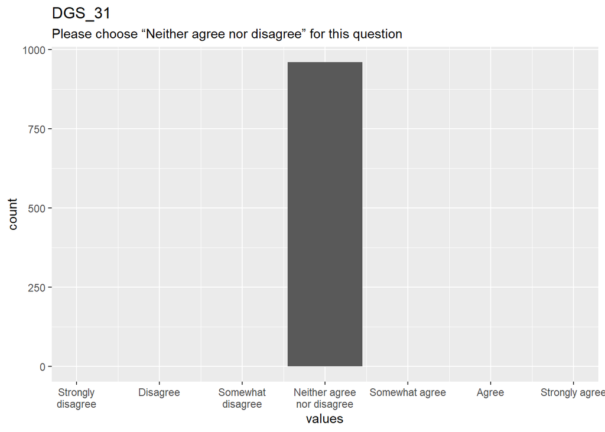

Distribution of values for DGS_31

0 missing values.

#### Summary statistics

| name | label | data_type | n_missing | complete_rate | min | median | max | mean | sd | n_value_labels | hist |
| --- | --- | --- | --- | --- | --- | --- | --- | --- | --- | --- | --- |
| DGS_31 | Please choose “Neither agree nor disagree” for this question | haven_labelled | 0 | 1 | 4 | 4 | 4 | 4 | 0 | 7 | ▁▁▁▇▁▁▁▁ |

#### Value labels

Response choices

| name | value |
| --- | --- |
| Strongly disagree | 1 |
| Disagree | 2 |
| Somewhat disagree | 3 |
| Neither agree nor disagree | 4 |
| Somewhat agree | 5 |
| Agree | 6 |
| Strongly agree | 7 |

### DGS_53

Please choose “Disagree” for this question

#### Distribution

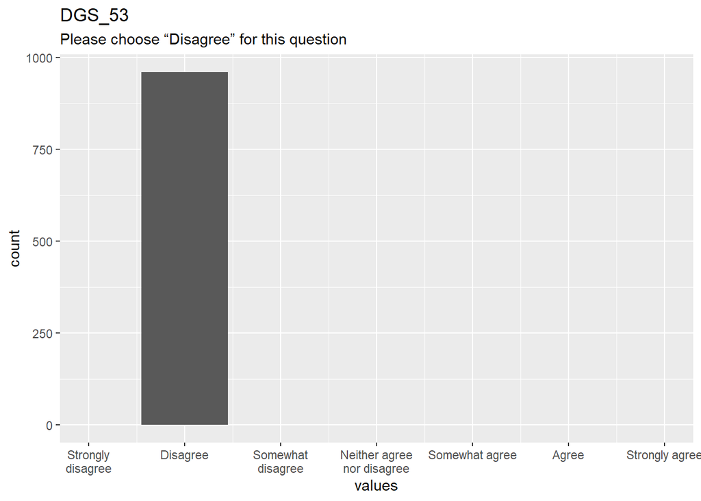

Distribution of values for DGS_53

0 missing values.

#### Summary statistics

| name | label | data_type | n_missing | complete_rate | min | median | max | mean | sd | n_value_labels | hist |
| --- | --- | --- | --- | --- | --- | --- | --- | --- | --- | --- | --- |
| DGS_53 | Please choose “Disagree” for this question | haven_labelled | 0 | 1 | 2 | 2 | 2 | 2 | 0 | 7 | ▁▁▁▇▁▁▁▁ |

#### Value labels

Response choices

| name | value |
| --- | --- |
| Strongly disagree | 1 |
| Disagree | 2 |
| Somewhat disagree | 3 |
| Neither agree nor disagree | 4 |
| Somewhat agree | 5 |
| Agree | 6 |
| Strongly agree | 7 |

### Age

Please indicate your age in years.

#### Distribution

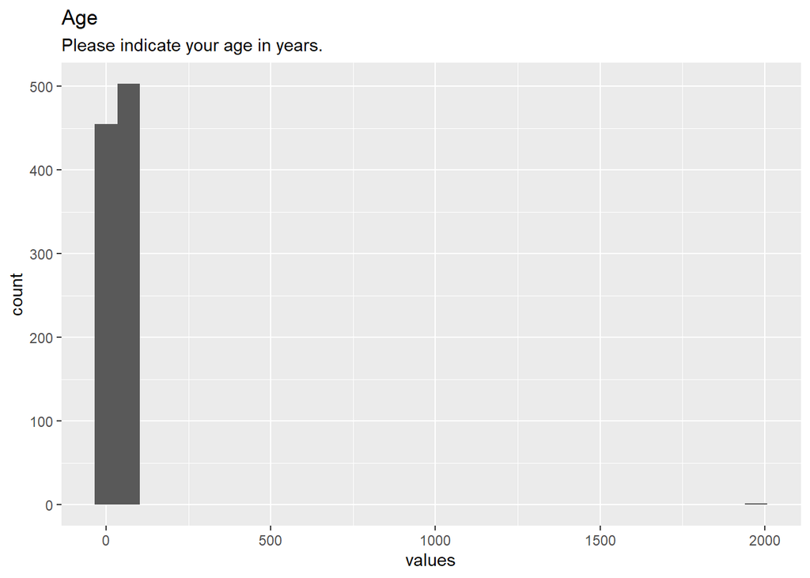

Distribution of values for Age

0 missing values.

#### Summary statistics

| name | label | data_type | n_missing | complete_rate | min | median | max | mean | sd | hist |
| --- | --- | --- | --- | --- | --- | --- | --- | --- | --- | --- |
| Age | Please indicate your age in years. | numeric | 0 | 1 | 18 | 35 | 1992 | 42.10938 | 89.84052 | ▇▁▁▁▁ |

### Gender

What gender do you identify as?

#### Distribution

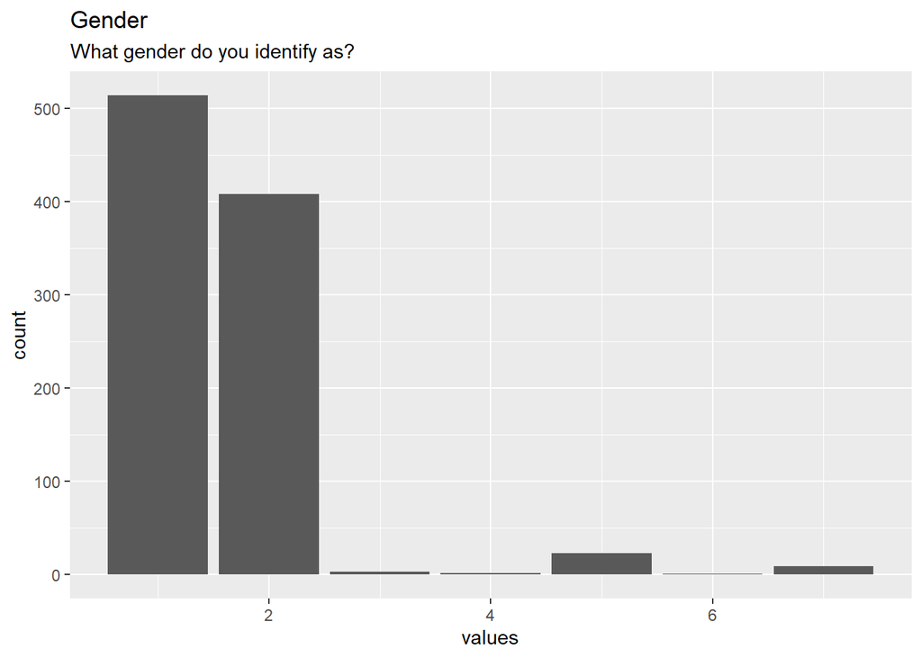

Distribution of values for Gender

0 missing values.

#### Summary statistics

| name | label | data_type | n_missing | complete_rate | min | median | max | mean | sd | hist |
| --- | --- | --- | --- | --- | --- | --- | --- | --- | --- | --- |
| Gender | What gender do you identify as? | numeric | 0 | 1 | 1 | 1 | 7 | 1.594792 | 0.9220811 | ▇▁▁▁▁ |

### Race

Please indicate your race (select all that apply)

#### Distribution

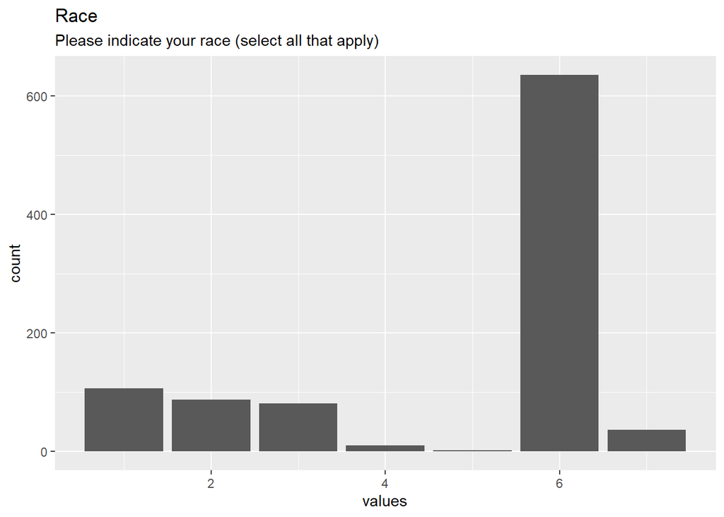

Distribution of values for Race

0 missing values.

#### Summary statistics

| name | label | data_type | n_missing | complete_rate | min | median | max | mean | sd | hist |
| --- | --- | --- | --- | --- | --- | --- | --- | --- | --- | --- |
| Race | Please indicate your race (select all that apply) | numeric | 0 | 1 | 1 | 6 | 7 | 4.838542 | 1.936417 | ▂▁▁▁▇ |

### Degree

Please indicate the highest degree or level of education that you have completed.

#### Distribution

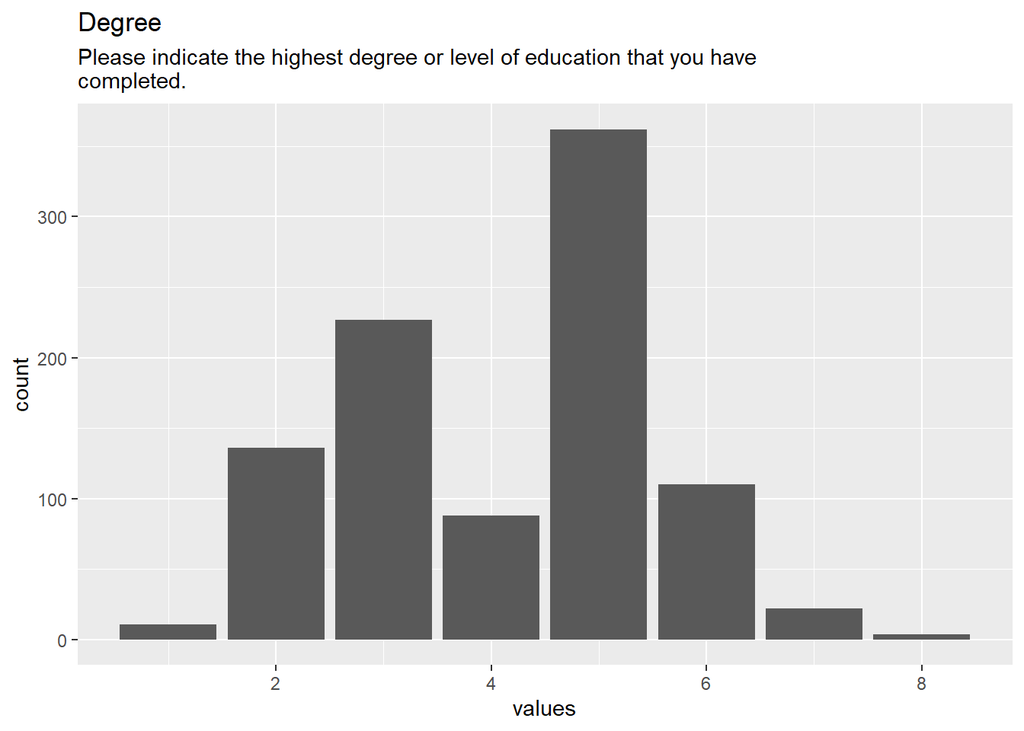

Distribution of values for Degree

0 missing values.

#### Summary statistics

| name | label | data_type | n_missing | complete_rate | min | median | max | mean | sd | hist |
| --- | --- | --- | --- | --- | --- | --- | --- | --- | --- | --- |
| Degree | Please indicate the highest degree or level of education that you have completed. | numeric | 0 | 1 | 1 | 5 | 8 | 4.1375 | 1.413421 | ▂▅▇▂▁ |

### Income

What is your household income?

#### Distribution

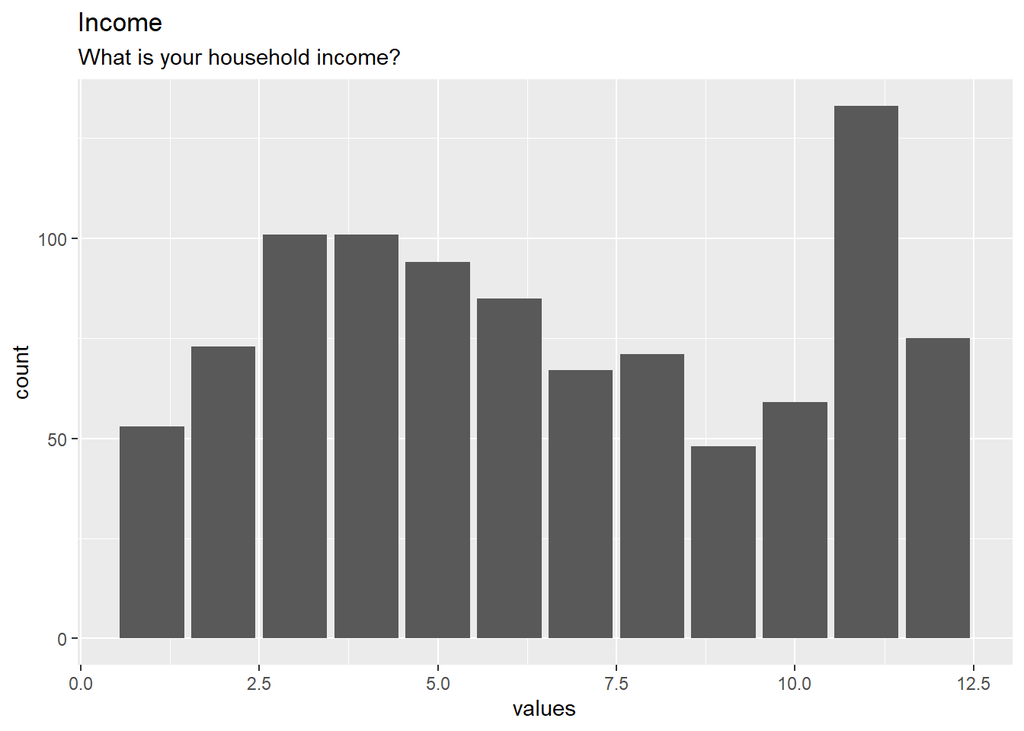

Distribution of values for Income

0 missing values.

#### Summary statistics

| name | label | data_type | n_missing | complete_rate | min | median | max | mean | sd | hist |
| --- | --- | --- | --- | --- | --- | --- | --- | --- | --- | --- |
| Income | What is your household income? | numeric | 0 | 1 | 1 | 6 | 12 | 6.570833 | 3.438599 | ▇▆▅▃▇ |

### Religion

What is your present religion, if any?

#### Distribution

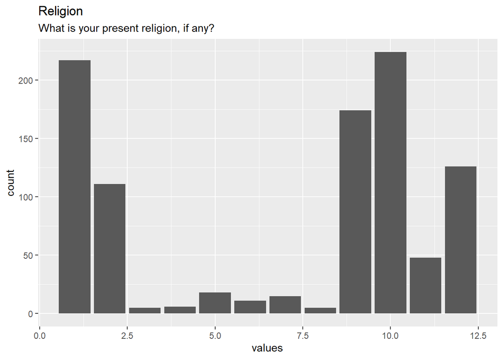

Distribution of values for Religion

0 missing values.

#### Summary statistics

| name | label | data_type | n_missing | complete_rate | min | median | max | mean | sd | hist |
| --- | --- | --- | --- | --- | --- | --- | --- | --- | --- | --- |
| Religion | What is your present religion, if any? | numeric | 0 | 1 | 1 | 9 | 12 | 6.901042 | 4.263187 | ▇▁▁▃▇ |

### Scale: DGS

#### Overview

**Reliability**: Not computed.

**Missing**: 0.

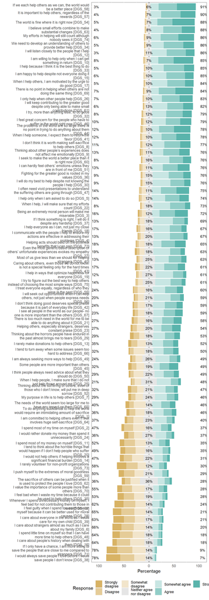

Likert plot of scale DGS items

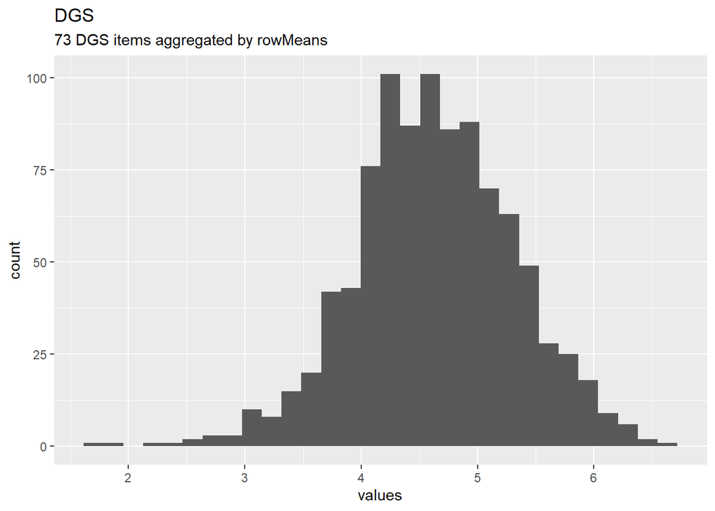

Distribution of scale DGS

#### Reliability details

#### Summary statistics

| name | label | data_type | value_labels | n_missing | complete_rate | min | median | max | mean | sd | n_value_labels | hist |
| --- | --- | --- | --- | --- | --- | --- | --- | --- | --- | --- | --- | --- |
| DGS_4 | I communicate with the people I help to ensure my actions are effective in addressing their problems | haven_labelled | 1. Strongly disagree, 2. Disagree, 3. Somewhat disagree, 4. Neither agree nor disagree, 5. Somewhat agree, 6. Agree, 7. Strongly agree | 0 | 1 | 1 | 5 | 7 | 4.901042 | 1.313124 | 7 | ▁▁▂▅▁▇▇▂ |
| DGS_12 | I will listen closely to the people that I help | haven_labelled | 1. Strongly disagree, 2. Disagree, 3. Somewhat disagree, 4. Neither agree nor disagree, 5. Somewhat agree, 6. Agree, 7. Strongly agree | 0 | 1 | 1 | 6 | 7 | 5.536458 | 1.061569 | 7 | ▁▁▁▂▁▆▇▃ |
| DGS_15 | I am happy to help despite not everyone doing it | haven_labelled | 1. Strongly disagree, 2. Disagree, 3. Somewhat disagree, 4. Neither agree nor disagree, 5. Somewhat agree, 6. Agree, 7. Strongly agree | 0 | 1 | 1 | 6 | 7 | 5.482292 | 1.136052 | 7 | ▁▁▁▂▁▆▇▃ |
| DGS_17 | When I help others, I am motivated by the urge to do good | haven_labelled | 1. Strongly disagree, 2. Disagree, 3. Somewhat disagree, 4. Neither agree nor disagree, 5. Somewhat agree, 6. Agree, 7. Strongly agree | 0 | 1 | 1 | 6 | 7 | 5.455208 | 1.155336 | 7 | ▁▁▁▂▁▇▇▃ |
| DGS_18 | I help everyone as I can, not just my close friends | haven_labelled | 1. Strongly disagree, 2. Disagree, 3. Somewhat disagree, 4. Neither agree nor disagree, 5. Somewhat agree, 6. Agree, 7. Strongly agree | 0 | 1 | 1 | 5 | 7 | 4.840625 | 1.406308 | 7 | ▁▁▂▃▁▇▆▂ |
| DGS_19 | I help in ways that optimize happiness for everyone | haven_labelled | 1. Strongly disagree, 2. Disagree, 3. Somewhat disagree, 4. Neither agree nor disagree, 5. Somewhat agree, 6. Agree, 7. Strongly agree | 0 | 1 | 1 | 5 | 7 | 4.758333 | 1.213383 | 7 | ▁▁▂▆▁▇▅▂ |
| DGS_22 | When I help, I will make sure that my efforts count | haven_labelled | 1. Strongly disagree, 2. Disagree, 3. Somewhat disagree, 4. Neither agree nor disagree, 5. Somewhat agree, 6. Agree, 7. Strongly agree | 0 | 1 | 1 | 5 | 7 | 5.114583 | 1.208846 | 7 | ▁▁▁▅▁▇▇▂ |
| DGS_30 | I will do my best to help despite not knowing the people I help | haven_labelled | 1. Strongly disagree, 2. Disagree, 3. Somewhat disagree, 4. Neither agree nor disagree, 5. Somewhat agree, 6. Agree, 7. Strongly agree | 0 | 1 | 1 | 5 | 7 | 5.139583 | 1.260326 | 7 | ▁▁▁▃▁▇▆▃ |
| DGS_32 | I try, more than anything else, to do good | haven_labelled | 1. Strongly disagree, 2. Disagree, 3. Somewhat disagree, 4. Neither agree nor disagree, 5. Somewhat agree, 6. Agree, 7. Strongly agree | 0 | 1 | 1 | 6 | 7 | 5.355208 | 1.274550 | 7 | ▁▁▁▃▁▇▇▅ |
| DGS_33 | I help because I think it is the best thing to do | haven_labelled | 1. Strongly disagree, 2. Disagree, 3. Somewhat disagree, 4. Neither agree nor disagree, 5. Somewhat agree, 6. Agree, 7. Strongly agree | 0 | 1 | 1 | 6 | 7 | 5.583333 | 1.139550 | 7 | ▁▁▁▂▁▅▇▃ |
| DGS_34 | We need to develop an understanding of others to provide better help | haven_labelled | 1. Strongly disagree, 2. Disagree, 3. Somewhat disagree, 4. Neither agree nor disagree, 5. Somewhat agree, 6. Agree, 7. Strongly agree | 0 | 1 | 1 | 6 | 7 | 5.596875 | 1.175431 | 7 | ▁▁▁▂▁▅▇▅ |
| DGS_36 | Fighting for the greater good is rooted in my values | haven_labelled | 1. Strongly disagree, 2. Disagree, 3. Somewhat disagree, 4. Neither agree nor disagree, 5. Somewhat agree, 6. Agree, 7. Strongly agree | 0 | 1 | 1 | 5 | 7 | 5.203125 | 1.279252 | 7 | ▁▁▁▃▁▇▇▃ |
| DGS_37 | If I think something is right, I will do it despite any hardship | haven_labelled | 1. Strongly disagree, 2. Disagree, 3. Somewhat disagree, 4. Neither agree nor disagree, 5. Somewhat agree, 6. Agree, 7. Strongly agree | 0 | 1 | 1 | 5 | 7 | 4.876042 | 1.214377 | 7 | ▁▁▂▃▁▇▅▂ |
| DGS_49 | I am always seeking more ways to help | haven_labelled | 1. Strongly disagree, 2. Disagree, 3. Somewhat disagree, 4. Neither agree nor disagree, 5. Somewhat agree, 6. Agree, 7. Strongly agree | 0 | 1 | 1 | 4 | 7 | 4.387500 | 1.432474 | 7 | ▁▂▃▇▁▇▅▂ |
| DGS_55 | I treat everyone equally, regardless of who they were in the past | haven_labelled | 1. Strongly disagree, 2. Disagree, 3. Somewhat disagree, 4. Neither agree nor disagree, 5. Somewhat agree, 6. Agree, 7. Strongly agree | 0 | 1 | 1 | 5 | 7 | 4.733333 | 1.527548 | 7 | ▁▂▅▅▁▇▇▃ |
| DGS_57 | It is important to help others, regardless of the rewards | haven_labelled | 1. Strongly disagree, 2. Disagree, 3. Somewhat disagree, 4. Neither agree nor disagree, 5. Somewhat agree, 6. Agree, 7. Strongly agree | 0 | 1 | 1 | 6 | 7 | 5.817708 | 1.136694 | 7 | ▁▁▁▂▁▅▇▆ |
| DGS_58 | If we each help others as we can, the world would be a better place | haven_labelled | 1. Strongly disagree, 2. Disagree, 3. Somewhat disagree, 4. Neither agree nor disagree, 5. Somewhat agree, 6. Agree, 7. Strongly agree | 0 | 1 | 1 | 6 | 7 | 5.980208 | 1.108609 | 7 | ▁▁▁▁▁▃▇▇ |
| DGS_60 | I seek to make the world a better place than it is right now | haven_labelled | 1. Strongly disagree, 2. Disagree, 3. Somewhat disagree, 4. Neither agree nor disagree, 5. Somewhat agree, 6. Agree, 7. Strongly agree | 0 | 1 | 1 | 5 | 7 | 5.234375 | 1.259899 | 7 | ▁▁▁▃▁▇▇▃ |
| DGS_61 | I will keep contributing to the greater good despite only being able to make small contributions | haven_labelled | 1. Strongly disagree, 2. Disagree, 3. Somewhat disagree, 4. Neither agree nor disagree, 5. Somewhat agree, 6. Agree, 7. Strongly agree | 0 | 1 | 1 | 6 | 7 | 5.429167 | 1.217351 | 7 | ▁▁▁▃▁▇▇▅ |
| DGS_63 | I believe small efforts combine to make substantial changes | haven_labelled | 1. Strongly disagree, 2. Disagree, 3. Somewhat disagree, 4. Neither agree nor disagree, 5. Somewhat agree, 6. Agree, 7. Strongly agree | 0 | 1 | 1 | 6 | 7 | 5.697917 | 1.159085 | 7 | ▁▁▁▂▁▆▇▆ |
| DGS_74 | My efforts in helping will still count although nobody sees it | haven_labelled | 1. Strongly disagree, 2. Disagree, 3. Somewhat disagree, 4. Neither agree nor disagree, 5. Somewhat agree, 6. Agree, 7. Strongly agree | 0 | 1 | 1 | 6 | 7 | 5.757292 | 1.223871 | 7 | ▁▁▁▂▁▅▇▇ |
| DGS_75 | I try to figure out the best way to help others instead of choosing the most simple ways | haven_labelled | 1. Strongly disagree, 2. Disagree, 3. Somewhat disagree, 4. Neither agree nor disagree, 5. Somewhat agree, 6. Agree, 7. Strongly agree | 0 | 1 | 1 | 5 | 7 | 4.787500 | 1.275685 | 7 | ▁▁▂▆▁▇▆▂ |
| DGS_5 | I help only when I am asked to do so | haven_labelled | 7. Strongly disagree, 6. Disagree, 5. Somewhat disagree, 4. Neither agree nor disagree, 3. Somewhat agree, 2. Agree, 1. Strongly agree | 0 | 1 | 1 | 5 | 7 | 5.194792 | 1.434919 | 7 | ▁▁▂▃▁▇▇▅ |
| DGS_10 | I am willing to help only when I can get something in return | haven_labelled | 7. Strongly disagree, 6. Disagree, 5. Somewhat disagree, 4. Neither agree nor disagree, 3. Somewhat agree, 2. Agree, 1. Strongly agree | 0 | 1 | 1 | 6 | 7 | 5.823958 | 1.345928 | 7 | ▁▁▁▂▁▃▆▇ |
| DGS_23 | Helping others, especially strangers, deserves constant praise | haven_labelled | 7. Strongly disagree, 6. Disagree, 5. Somewhat disagree, 4. Neither agree nor disagree, 3. Somewhat agree, 2. Agree, 1. Strongly agree | 0 | 1 | 1 | 5 | 7 | 4.661458 | 1.706570 | 7 | ▁▃▆▇▁▆▇▆ |
| DGS_26 | I only help when other people help | haven_labelled | 7. Strongly disagree, 6. Disagree, 5. Somewhat disagree, 4. Neither agree nor disagree, 3. Somewhat agree, 2. Agree, 1. Strongly agree | 0 | 1 | 1 | 6 | 7 | 5.598958 | 1.268286 | 7 | ▁▁▁▂▁▅▇▆ |
| DGS_41 | When I help someone, I expect them to return the favor | haven_labelled | 7. Strongly disagree, 6. Disagree, 5. Somewhat disagree, 4. Neither agree nor disagree, 3. Somewhat agree, 2. Agree, 1. Strongly agree | 0 | 1 | 1 | 6 | 7 | 5.457292 | 1.434074 | 7 | ▁▁▂▂▁▆▇▇ |
| DGS_47 | I often need vivid presentations to understand the suffering others are going through | haven_labelled | 7. Strongly disagree, 6. Disagree, 5. Somewhat disagree, 4. Neither agree nor disagree, 3. Somewhat agree, 2. Agree, 1. Strongly agree | 0 | 1 | 1 | 6 | 7 | 5.364583 | 1.473575 | 7 | ▁▁▂▃▁▅▇▆ |
| DGS_54 | The world is fine where it is right now | haven_labelled | 7. Strongly disagree, 6. Disagree, 5. Somewhat disagree, 4. Neither agree nor disagree, 3. Somewhat agree, 2. Agree, 1. Strongly agree | 0 | 1 | 1 | 6 | 7 | 5.997917 | 1.227932 | 7 | ▁▁▁▁▁▂▆▇ |
| DGS_69 | There is no point in helping when others are not doing the same thing | haven_labelled | 7. Strongly disagree, 6. Disagree, 5. Somewhat disagree, 4. Neither agree nor disagree, 3. Somewhat agree, 2. Agree, 1. Strongly agree | 0 | 1 | 1 | 6 | 7 | 5.766667 | 1.322672 | 7 | ▁▁▁▂▁▃▇▇ |
| DGS_72 | Helping acts should build on the potential benefits that I can gain | haven_labelled | 7. Strongly disagree, 6. Disagree, 5. Somewhat disagree, 4. Neither agree nor disagree, 3. Somewhat agree, 2. Agree, 1. Strongly agree | 0 | 1 | 1 | 5 | 7 | 5.100000 | 1.550135 | 7 | ▁▁▃▅▁▅▇▆ |
| DGS_9 | Thinking about other people’s experiences does not affect me emotionally | haven_labelled | 7. Strongly disagree, 6. Disagree, 5. Somewhat disagree, 4. Neither agree nor disagree, 3. Somewhat agree, 2. Agree, 1. Strongly agree | 0 | 1 | 1 | 6 | 7 | 5.288542 | 1.466012 | 7 | ▁▁▂▃▁▆▇▅ |
| DGS_20 | I tend to think about the horrible things that would happen if I don’t help people who suffer | haven_labelled | 1. Strongly disagree, 2. Disagree, 3. Somewhat disagree, 4. Neither agree nor disagree, 5. Somewhat agree, 6. Agree, 7. Strongly agree | 0 | 1 | 1 | 4 | 7 | 3.648958 | 1.665668 | 7 | ▃▇▇▆▁▇▅▂ |
| DGS_27 | Even the most generic/basic description of others’ unfortunate experiences evokes my empathy | haven_labelled | 1. Strongly disagree, 2. Disagree, 3. Somewhat disagree, 4. Neither agree nor disagree, 5. Somewhat agree, 6. Agree, 7. Strongly agree | 0 | 1 | 1 | 5 | 7 | 4.685417 | 1.466695 | 7 | ▁▁▂▅▁▇▅▂ |
| DGS_29 | Thinking about the horrors people have endured in the past almost brings me to tears | haven_labelled | 1. Strongly disagree, 2. Disagree, 3. Somewhat disagree, 4. Neither agree nor disagree, 5. Somewhat agree, 6. Agree, 7. Strongly agree | 0 | 1 | 1 | 5 | 7 | 4.391667 | 1.740978 | 7 | ▂▃▃▆▁▇▆▃ |
| DGS_46 | I feel great concern for the people who have to suffer in the world right now | haven_labelled | 1. Strongly disagree, 2. Disagree, 3. Somewhat disagree, 4. Neither agree nor disagree, 5. Somewhat agree, 6. Agree, 7. Strongly agree | 0 | 1 | 1 | 6 | 7 | 5.356250 | 1.376157 | 7 | ▁▁▂▃▁▇▇▆ |
| DGS_52 | Thinking about the suffering of others, even of those who I don’t know, will put me in deep sorrow | haven_labelled | 1. Strongly disagree, 2. Disagree, 3. Somewhat disagree, 4. Neither agree nor disagree, 5. Somewhat agree, 6. Agree, 7. Strongly agree | 0 | 1 | 1 | 4 | 7 | 4.220833 | 1.659549 | 7 | ▂▅▅▇▁▇▆▂ |
| DGS_2 | I spend most of my time on myself | haven_labelled | 7. Strongly disagree, 6. Disagree, 5. Somewhat disagree, 4. Neither agree nor disagree, 3. Somewhat agree, 2. Agree, 1. Strongly agree | 0 | 1 | 1 | 4 | 7 | 3.892708 | 1.662300 | 7 | ▂▆▇▅▁▆▅▂ |
| DGS_11 | I spend most of my money on myself | haven_labelled | 7. Strongly disagree, 6. Disagree, 5. Somewhat disagree, 4. Neither agree nor disagree, 3. Somewhat agree, 2. Agree, 1. Strongly agree | 0 | 1 | 1 | 3 | 7 | 3.727083 | 1.796908 | 7 | ▃▇▇▅▁▅▅▃ |
| DGS_28 | I feel guilty when I spend too much time on myself because it can be better used for moral causes | haven_labelled | 1. Strongly disagree, 2. Disagree, 3. Somewhat disagree, 4. Neither agree nor disagree, 5. Somewhat agree, 6. Agree, 7. Strongly agree | 0 | 1 | 1 | 3 | 7 | 3.078125 | 1.605887 | 7 | ▅▇▇▅▁▃▂▁ |
| DGS_35 | I feel bad when I waste my time because it could be used to help others | haven_labelled | 1. Strongly disagree, 2. Disagree, 3. Somewhat disagree, 4. Neither agree nor disagree, 5. Somewhat agree, 6. Agree, 7. Strongly agree | 0 | 1 | 1 | 3 | 7 | 3.427083 | 1.609052 | 7 | ▅▇▇▇▁▇▂▂ |
| DGS_48 | I spend little time on myself so that I can have more time to help others | haven_labelled | 1. Strongly disagree, 2. Disagree, 3. Somewhat disagree, 4. Neither agree nor disagree, 5. Somewhat agree, 6. Agree, 7. Strongly agree | 0 | 1 | 1 | 3 | 7 | 3.092708 | 1.516936 | 7 | ▅▇▇▆▁▃▂▁ |
| DGS_59 | I push myself to the extremes of moral goodness | haven_labelled | 1. Strongly disagree, 2. Disagree, 3. Somewhat disagree, 4. Neither agree nor disagree, 5. Somewhat agree, 6. Agree, 7. Strongly agree | 0 | 1 | 1 | 4 | 7 | 3.526042 | 1.605306 | 7 | ▃▇▇▇▁▆▃▁ |
| DGS_64 | I am committed to helping others even if that involves huge self-sacrifice | haven_labelled | 1. Strongly disagree, 2. Disagree, 3. Somewhat disagree, 4. Neither agree nor disagree, 5. Somewhat agree, 6. Agree, 7. Strongly agree | 0 | 1 | 1 | 4 | 7 | 4.007292 | 1.505966 | 7 | ▂▅▆▇▁▇▃▂ |
| DGS_68 | Whenever I spend unnecessary money on myself, I feel bad for not contributing them to those in need | haven_labelled | 1. Strongly disagree, 2. Disagree, 3. Somewhat disagree, 4. Neither agree nor disagree, 5. Somewhat agree, 6. Agree, 7. Strongly agree | 0 | 1 | 1 | 3 | 7 | 3.159375 | 1.659370 | 7 | ▆▇▇▅▁▅▂▁ |
| DGS_1 | To do anything substantial to help the world would require an intimidating amount of sacrifice | haven_labelled | 7. Strongly disagree, 6. Disagree, 5. Somewhat disagree, 4. Neither agree nor disagree, 3. Somewhat agree, 2. Agree, 1. Strongly agree | 0 | 1 | 1 | 4 | 7 | 4.210417 | 1.683972 | 7 | ▂▅▇▇▁▇▆▃ |
| DGS_21 | There is too much need in the world for me to be able to do anything about it | haven_labelled | 7. Strongly disagree, 6. Disagree, 5. Somewhat disagree, 4. Neither agree nor disagree, 3. Somewhat agree, 2. Agree, 1. Strongly agree | 0 | 1 | 1 | 5 | 7 | 4.691667 | 1.707108 | 7 | ▂▂▅▆▁▆▇▆ |
| DGS_44 | The problems of the world are so large there is no point in trying to do anything about them | haven_labelled | 7. Strongly disagree, 6. Disagree, 5. Somewhat disagree, 4. Neither agree nor disagree, 3. Somewhat agree, 2. Agree, 1. Strongly agree | 0 | 1 | 1 | 6 | 7 | 5.557292 | 1.490620 | 7 | ▁▁▂▂▁▃▇▇ |
| DGS_65 | The needs of the world seem too large for me to have any impact on them | haven_labelled | 7. Strongly disagree, 6. Disagree, 5. Somewhat disagree, 4. Neither agree nor disagree, 3. Somewhat agree, 2. Agree, 1. Strongly agree | 0 | 1 | 1 | 4 | 7 | 4.218750 | 1.758063 | 7 | ▂▃▇▅▁▆▆▃ |
| DGS_6 | I care about strangers almost as much as I care about my family | haven_labelled | 1. Strongly disagree, 2. Disagree, 3. Somewhat disagree, 4. Neither agree nor disagree, 5. Somewhat agree, 6. Agree, 7. Strongly agree | 0 | 1 | 1 | 3 | 7 | 3.043750 | 1.578057 | 7 | ▆▇▇▅▁▃▂▁ |
| DGS_38 | I would always save people I love before I would save people I don’t know | haven_labelled | 7. Strongly disagree, 6. Disagree, 5. Somewhat disagree, 4. Neither agree nor disagree, 3. Somewhat agree, 2. Agree, 1. Strongly agree | 0 | 1 | 1 | 2 | 7 | 2.491667 | 1.347741 | 7 | ▇▇▆▅▁▁▁▁ |
| DGS_39 | I care about everyone in the world as I would care for my own child | haven_labelled | 1. Strongly disagree, 2. Disagree, 3. Somewhat disagree, 4. Neither agree nor disagree, 5. Somewhat agree, 6. Agree, 7. Strongly agree | 0 | 1 | 1 | 3 | 7 | 3.054167 | 1.640590 | 7 | ▇▇▇▆▁▅▂▁ |
| DGS_45 | Some people are more important than others | haven_labelled | 7. Strongly disagree, 6. Disagree, 5. Somewhat disagree, 4. Neither agree nor disagree, 3. Somewhat agree, 2. Agree, 1. Strongly agree | 0 | 1 | 1 | 4 | 7 | 4.502083 | 1.842607 | 7 | ▃▃▆▇▁▅▇▇ |
| DGS_67 | I see all people in the world as our people- no one is more important than the others | haven_labelled | 1. Strongly disagree, 2. Disagree, 3. Somewhat disagree, 4. Neither agree nor disagree, 5. Somewhat agree, 6. Agree, 7. Strongly agree | 0 | 1 | 1 | 5 | 7 | 4.747917 | 1.629049 | 7 | ▁▂▅▆▁▇▇▅ |
| DGS_70 | I value the importance of some people more than others | haven_labelled | 7. Strongly disagree, 6. Disagree, 5. Somewhat disagree, 4. Neither agree nor disagree, 3. Somewhat agree, 2. Agree, 1. Strongly agree | 0 | 1 | 1 | 3 | 7 | 3.565625 | 1.687180 | 7 | ▃▆▇▆▁▃▃▂ |
| DGS_71 | If I only have a chance, I am more willing to save the people that are close to me compared to strangers | haven_labelled | 7. Strongly disagree, 6. Disagree, 5. Somewhat disagree, 4. Neither agree nor disagree, 3. Somewhat agree, 2. Agree, 1. Strongly agree | 0 | 1 | 1 | 2 | 7 | 2.641667 | 1.341071 | 7 | ▆▇▇▃▁▁▁▁ |
| DGS_3 | Being an extremely moral person will make me miserable | haven_labelled | 7. Strongly disagree, 6. Disagree, 5. Somewhat disagree, 4. Neither agree nor disagree, 3. Somewhat agree, 2. Agree, 1. Strongly agree | 0 | 1 | 1 | 6 | 7 | 5.268750 | 1.622529 | 7 | ▁▁▂▃▁▃▇▆ |
| DGS_7 | My purpose in life is to help others | haven_labelled | 1. Strongly disagree, 2. Disagree, 3. Somewhat disagree, 4. Neither agree nor disagree, 5. Somewhat agree, 6. Agree, 7. Strongly agree | 0 | 1 | 1 | 4 | 7 | 4.271875 | 1.564745 | 7 | ▂▃▅▇▁▇▅▂ |
| DGS_8 | I don’t think it is worth making self-sacrifice to help others | haven_labelled | 7. Strongly disagree, 6. Disagree, 5. Somewhat disagree, 4. Neither agree nor disagree, 3. Somewhat agree, 2. Agree, 1. Strongly agree | 0 | 1 | 1 | 6 | 7 | 5.336458 | 1.367858 | 7 | ▁▁▂▃▁▆▇▅ |
| DGS_13 | I rarely make donations to help others | haven_labelled | 7. Strongly disagree, 6. Disagree, 5. Somewhat disagree, 4. Neither agree nor disagree, 3. Somewhat agree, 2. Agree, 1. Strongly agree | 0 | 1 | 1 | 5 | 7 | 4.328125 | 1.730437 | 7 | ▂▅▆▅▁▇▇▃ |
| DGS_14 | I would not help others if helping involves a significant financial burden | haven_labelled | 7. Strongly disagree, 6. Disagree, 5. Somewhat disagree, 4. Neither agree nor disagree, 3. Somewhat agree, 2. Agree, 1. Strongly agree | 0 | 1 | 1 | 4 | 7 | 3.709375 | 1.582594 | 7 | ▃▆▇▇▁▆▃▂ |
| DGS_16 | I care about people’s history when dealing with them | haven_labelled | 7. Strongly disagree, 6. Disagree, 5. Somewhat disagree, 4. Neither agree nor disagree, 3. Somewhat agree, 2. Agree, 1. Strongly agree | 0 | 1 | 1 | 3 | 7 | 3.221875 | 1.470510 | 7 | ▂▇▇▅▁▂▂▁ |
| DGS_24 | I would rather donate my money than spend it unnecessarily | haven_labelled | 1. Strongly disagree, 2. Disagree, 3. Somewhat disagree, 4. Neither agree nor disagree, 5. Somewhat agree, 6. Agree, 7. Strongly agree | 0 | 1 | 1 | 4 | 7 | 3.936458 | 1.569098 | 7 | ▂▃▅▇▁▆▃▂ |
| DGS_25 | When I help people, I make sure that I do not just help those around me | haven_labelled | 1. Strongly disagree, 2. Disagree, 3. Somewhat disagree, 4. Neither agree nor disagree, 5. Somewhat agree, 6. Agree, 7. Strongly agree | 0 | 1 | 1 | 4 | 7 | 4.431250 | 1.293870 | 7 | ▁▂▃▇▁▇▃▁ |
| DGS_40 | Most of us give less than we should for helping strangers | haven_labelled | 1. Strongly disagree, 2. Disagree, 3. Somewhat disagree, 4. Neither agree nor disagree, 5. Somewhat agree, 6. Agree, 7. Strongly agree | 0 | 1 | 1 | 5 | 7 | 4.877083 | 1.362195 | 7 | ▁▁▂▇▁▇▇▃ |
| DGS_42 | I don’t think doing good deserves special praise because it is part of everyday life | haven_labelled | 1. Strongly disagree, 2. Disagree, 3. Somewhat disagree, 4. Neither agree nor disagree, 5. Somewhat agree, 6. Agree, 7. Strongly agree | 0 | 1 | 1 | 5 | 7 | 4.702083 | 1.564996 | 7 | ▁▂▅▆▁▇▇▅ |
| DGS_43 | Caring about others, even those we do not know, is not a special feeling only for the hard times | haven_labelled | 1. Strongly disagree, 2. Disagree, 3. Somewhat disagree, 4. Neither agree nor disagree, 5. Somewhat agree, 6. Agree, 7. Strongly agree | 0 | 1 | 1 | 5 | 7 | 4.862500 | 1.587178 | 7 | ▂▂▂▆▁▆▇▅ |
| DGS_50 | I think people always need advice about what they should do | haven_labelled | 7. Strongly disagree, 6. Disagree, 5. Somewhat disagree, 4. Neither agree nor disagree, 3. Somewhat agree, 2. Agree, 1. Strongly agree | 0 | 1 | 1 | 4 | 7 | 4.463542 | 1.544179 | 7 | ▁▂▇▇▁▇▇▃ |
| DGS_51 | I can hardly feel others’ emotions unless they are in front of me | haven_labelled | 7. Strongly disagree, 6. Disagree, 5. Somewhat disagree, 4. Neither agree nor disagree, 3. Somewhat agree, 2. Agree, 1. Strongly agree | 0 | 1 | 1 | 6 | 7 | 5.323958 | 1.474231 | 7 | ▁▁▂▃▁▆▇▆ |
| DGS_56 | I will seek out opportunities when I can help others, not just when people express needs | haven_labelled | 1. Strongly disagree, 2. Disagree, 3. Somewhat disagree, 4. Neither agree nor disagree, 5. Somewhat agree, 6. Agree, 7. Strongly agree | 0 | 1 | 1 | 5 | 7 | 4.627083 | 1.389104 | 7 | ▁▂▃▅▁▇▅▂ |
| DGS_62 | The sacrifice of others can be justified when it is used to protect the people I love | haven_labelled | 7. Strongly disagree, 6. Disagree, 5. Somewhat disagree, 4. Neither agree nor disagree, 3. Somewhat agree, 2. Agree, 1. Strongly agree | 0 | 1 | 1 | 4 | 7 | 3.867708 | 1.451402 | 7 | ▂▂▅▇▁▃▂▁ |
| DGS_66 | I tend to turn away when some issues seem too hard to address | haven_labelled | 7. Strongly disagree, 6. Disagree, 5. Somewhat disagree, 4. Neither agree nor disagree, 3. Somewhat agree, 2. Agree, 1. Strongly agree | 0 | 1 | 1 | 5 | 7 | 4.462500 | 1.564948 | 7 | ▁▃▇▆▁▇▇▃ |
| DGS_73 | I rarely volunteer for non-profit organizations | haven_labelled | 7. Strongly disagree, 6. Disagree, 5. Somewhat disagree, 4. Neither agree nor disagree, 3. Somewhat agree, 2. Agree, 1. Strongly agree | 0 | 1 | 1 | 3 | 7 | 3.333333 | 1.834478 | 7 | ▆▇▆▅▁▅▃▂ |

### Scale: HEXACO_C

#### Overview

**Reliability**: Not computed.

**Missing**: 0.

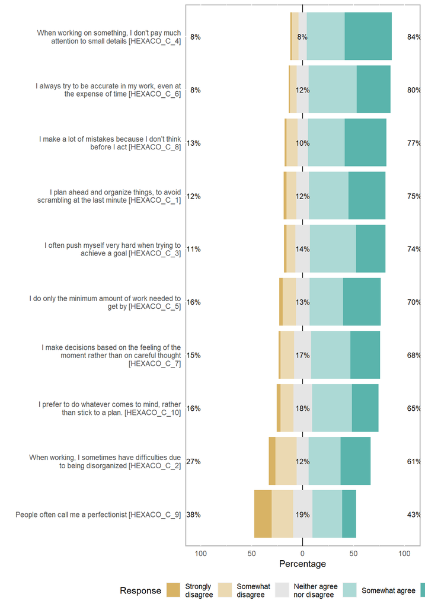

Likert plot of scale HEXACO_C items

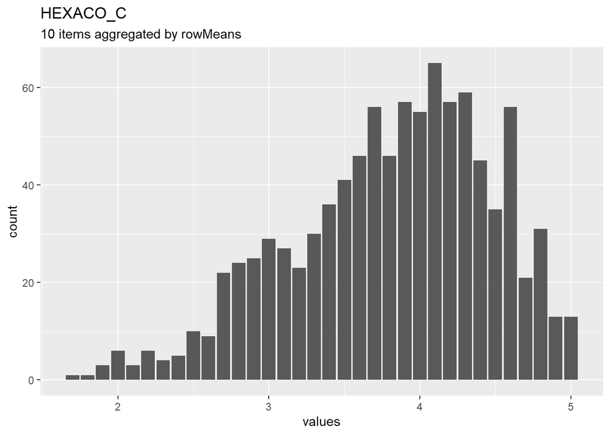

Distribution of scale HEXACO_C

#### Reliability details

#### Summary statistics

| name | label | data_type | value_labels | n_missing | complete_rate | min | median | max | mean | sd | n_value_labels | hist |
| --- | --- | --- | --- | --- | --- | --- | --- | --- | --- | --- | --- | --- |
| HEXACO_C_1 | I plan ahead and organize things, to avoid scrambling at the last minute | haven_labelled | 1. Strongly disagree, 2. Somewhat disagree, 3. Neither agree nor disagree, 4. Somewhat agree, 5. Strongly agree | 0 | 1 | 1 | 4 | 5 | 3.959375 | 1.0589583 | 5 | ▁▂▁▂▁▇▁▇ |
| HEXACO_C_2 | When working, I sometimes have difficulties due to being disorganized | haven_labelled | 5. Strongly disagree, 4. Somewhat disagree, 3. Neither agree nor disagree, 2. Somewhat agree, 1. Strongly agree | 0 | 1 | 1 | 4 | 5 | 3.563542 | 1.2811800 | 5 | ▂▅▁▃▁▇▁▇ |
| HEXACO_C_3 | I often push myself very hard when trying to achieve a goal | haven_labelled | 1. Strongly disagree, 2. Somewhat disagree, 3. Neither agree nor disagree, 4. Somewhat agree, 5. Strongly agree | 0 | 1 | 1 | 4 | 5 | 3.892708 | 1.0077639 | 5 | ▁▂▁▂▁▇▁▅ |
| HEXACO_C_4 | When working on something, I don’t pay much attention to small details | haven_labelled | 5. Strongly disagree, 4. Somewhat disagree, 3. Neither agree nor disagree, 2. Somewhat agree, 1. Strongly agree | 0 | 1 | 1 | 4 | 5 | 4.201042 | 0.9591223 | 5 | ▁▁▁▂▁▆▁▇ |
| HEXACO_C_5 | I do only the minimum amount of work needed to get by | haven_labelled | 5. Strongly disagree, 4. Somewhat disagree, 3. Neither agree nor disagree, 2. Somewhat agree, 1. Strongly agree | 0 | 1 | 1 | 4 | 5 | 3.870833 | 1.1534883 | 5 | ▁▃▁▃▁▇▁▇ |
| HEXACO_C_6 | I always try to be accurate in my work, even at the expense of time | haven_labelled | 1. Strongly disagree, 2. Somewhat disagree, 3. Neither agree nor disagree, 4. Somewhat agree, 5. Strongly agree | 0 | 1 | 1 | 4 | 5 | 4.051042 | 0.9009895 | 5 | ▁▁▁▂▁▇▁▆ |
| HEXACO_C_7 | I make decisions based on the feeling of the moment rather than on careful thought | haven_labelled | 5. Strongly disagree, 4. Somewhat disagree, 3. Neither agree nor disagree, 2. Somewhat agree, 1. Strongly agree | 0 | 1 | 1 | 4 | 5 | 3.798958 | 1.0671896 | 5 | ▁▃▁▃▁▇▁▆ |
| HEXACO_C_8 | I make a lot of mistakes because I don’t think before I act | haven_labelled | 5. Strongly disagree, 4. Somewhat disagree, 3. Neither agree nor disagree, 2. Somewhat agree, 1. Strongly agree | 0 | 1 | 1 | 4 | 5 | 4.034375 | 1.0522659 | 5 | ▁▂▁▂▁▇▁▇ |
| HEXACO_C_9 | People often call me a perfectionist | haven_labelled | 1. Strongly disagree, 2. Somewhat disagree, 3. Neither agree nor disagree, 4. Somewhat agree, 5. Strongly agree | 0 | 1 | 1 | 3 | 5 | 3.014583 | 1.3171666 | 5 | ▅▆▁▅▁▇▁▃ |
| HEXACO_C_10 | I prefer to do whatever comes to mind, rather than stick to a plan. | haven_labelled | 5. Strongly disagree, 4. Somewhat disagree, 3. Neither agree nor disagree, 2. Somewhat agree, 1. Strongly agree | 0 | 1 | 1 | 4 | 5 | 3.711458 | 1.0955755 | 5 | ▁▂▁▃▁▇▁▅ |

### Scale: M6_1

#### Overview

**Reliability**: Not computed.

**Missing**: 0.

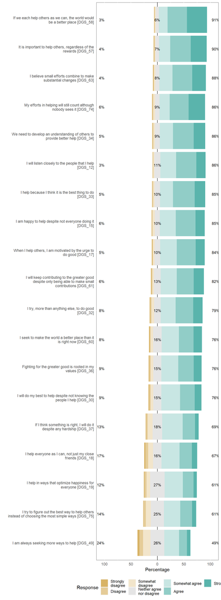

Likert plot of scale M6_1 items

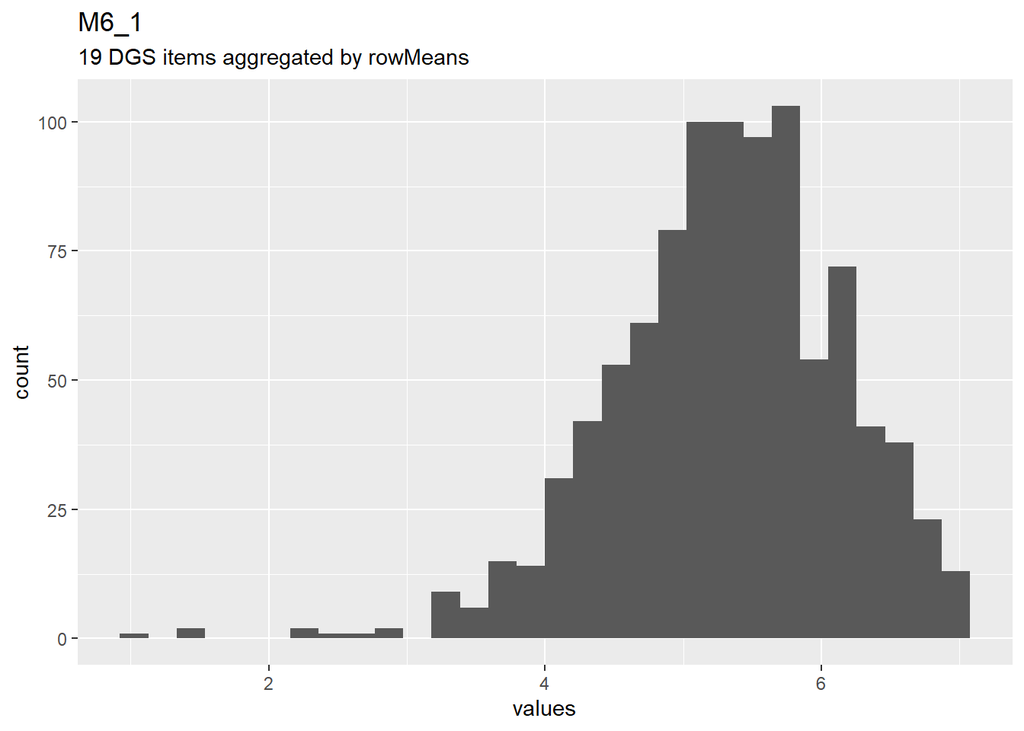

Distribution of scale M6_1

#### Reliability details

#### Summary statistics

| name | label | data_type | value_labels | n_missing | complete_rate | min | median | max | mean | sd | n_value_labels | hist |
| --- | --- | --- | --- | --- | --- | --- | --- | --- | --- | --- | --- | --- |
| DGS_12 | I will listen closely to the people that I help | haven_labelled | 1. Strongly disagree, 2. Disagree, 3. Somewhat disagree, 4. Neither agree nor disagree, 5. Somewhat agree, 6. Agree, 7. Strongly agree | 0 | 1 | 1 | 6 | 7 | 5.536458 | 1.061569 | 7 | ▁▁▁▂▁▆▇▃ |
| DGS_15 | I am happy to help despite not everyone doing it | haven_labelled | 1. Strongly disagree, 2. Disagree, 3. Somewhat disagree, 4. Neither agree nor disagree, 5. Somewhat agree, 6. Agree, 7. Strongly agree | 0 | 1 | 1 | 6 | 7 | 5.482292 | 1.136052 | 7 | ▁▁▁▂▁▆▇▃ |
| DGS_17 | When I help others, I am motivated by the urge to do good | haven_labelled | 1. Strongly disagree, 2. Disagree, 3. Somewhat disagree, 4. Neither agree nor disagree, 5. Somewhat agree, 6. Agree, 7. Strongly agree | 0 | 1 | 1 | 6 | 7 | 5.455208 | 1.155336 | 7 | ▁▁▁▂▁▇▇▃ |
| DGS_18 | I help everyone as I can, not just my close friends | haven_labelled | 1. Strongly disagree, 2. Disagree, 3. Somewhat disagree, 4. Neither agree nor disagree, 5. Somewhat agree, 6. Agree, 7. Strongly agree | 0 | 1 | 1 | 5 | 7 | 4.840625 | 1.406308 | 7 | ▁▁▂▃▁▇▆▂ |
| DGS_19 | I help in ways that optimize happiness for everyone | haven_labelled | 1. Strongly disagree, 2. Disagree, 3. Somewhat disagree, 4. Neither agree nor disagree, 5. Somewhat agree, 6. Agree, 7. Strongly agree | 0 | 1 | 1 | 5 | 7 | 4.758333 | 1.213383 | 7 | ▁▁▂▆▁▇▅▂ |
| DGS_30 | I will do my best to help despite not knowing the people I help | haven_labelled | 1. Strongly disagree, 2. Disagree, 3. Somewhat disagree, 4. Neither agree nor disagree, 5. Somewhat agree, 6. Agree, 7. Strongly agree | 0 | 1 | 1 | 5 | 7 | 5.139583 | 1.260326 | 7 | ▁▁▁▃▁▇▆▃ |
| DGS_32 | I try, more than anything else, to do good | haven_labelled | 1. Strongly disagree, 2. Disagree, 3. Somewhat disagree, 4. Neither agree nor disagree, 5. Somewhat agree, 6. Agree, 7. Strongly agree | 0 | 1 | 1 | 6 | 7 | 5.355208 | 1.274550 | 7 | ▁▁▁▃▁▇▇▅ |
| DGS_33 | I help because I think it is the best thing to do | haven_labelled | 1. Strongly disagree, 2. Disagree, 3. Somewhat disagree, 4. Neither agree nor disagree, 5. Somewhat agree, 6. Agree, 7. Strongly agree | 0 | 1 | 1 | 6 | 7 | 5.583333 | 1.139550 | 7 | ▁▁▁▂▁▅▇▃ |
| DGS_34 | We need to develop an understanding of others to provide better help | haven_labelled | 1. Strongly disagree, 2. Disagree, 3. Somewhat disagree, 4. Neither agree nor disagree, 5. Somewhat agree, 6. Agree, 7. Strongly agree | 0 | 1 | 1 | 6 | 7 | 5.596875 | 1.175431 | 7 | ▁▁▁▂▁▅▇▅ |
| DGS_36 | Fighting for the greater good is rooted in my values | haven_labelled | 1. Strongly disagree, 2. Disagree, 3. Somewhat disagree, 4. Neither agree nor disagree, 5. Somewhat agree, 6. Agree, 7. Strongly agree | 0 | 1 | 1 | 5 | 7 | 5.203125 | 1.279252 | 7 | ▁▁▁▃▁▇▇▃ |
| DGS_37 | If I think something is right, I will do it despite any hardship | haven_labelled | 1. Strongly disagree, 2. Disagree, 3. Somewhat disagree, 4. Neither agree nor disagree, 5. Somewhat agree, 6. Agree, 7. Strongly agree | 0 | 1 | 1 | 5 | 7 | 4.876042 | 1.214377 | 7 | ▁▁▂▃▁▇▅▂ |
| DGS_49 | I am always seeking more ways to help | haven_labelled | 1. Strongly disagree, 2. Disagree, 3. Somewhat disagree, 4. Neither agree nor disagree, 5. Somewhat agree, 6. Agree, 7. Strongly agree | 0 | 1 | 1 | 4 | 7 | 4.387500 | 1.432474 | 7 | ▁▂▃▇▁▇▅▂ |
| DGS_57 | It is important to help others, regardless of the rewards | haven_labelled | 1. Strongly disagree, 2. Disagree, 3. Somewhat disagree, 4. Neither agree nor disagree, 5. Somewhat agree, 6. Agree, 7. Strongly agree | 0 | 1 | 1 | 6 | 7 | 5.817708 | 1.136694 | 7 | ▁▁▁▂▁▅▇▆ |
| DGS_58 | If we each help others as we can, the world would be a better place | haven_labelled | 1. Strongly disagree, 2. Disagree, 3. Somewhat disagree, 4. Neither agree nor disagree, 5. Somewhat agree, 6. Agree, 7. Strongly agree | 0 | 1 | 1 | 6 | 7 | 5.980208 | 1.108609 | 7 | ▁▁▁▁▁▃▇▇ |
| DGS_60 | I seek to make the world a better place than it is right now | haven_labelled | 1. Strongly disagree, 2. Disagree, 3. Somewhat disagree, 4. Neither agree nor disagree, 5. Somewhat agree, 6. Agree, 7. Strongly agree | 0 | 1 | 1 | 5 | 7 | 5.234375 | 1.259899 | 7 | ▁▁▁▃▁▇▇▃ |
| DGS_61 | I will keep contributing to the greater good despite only being able to make small contributions | haven_labelled | 1. Strongly disagree, 2. Disagree, 3. Somewhat disagree, 4. Neither agree nor disagree, 5. Somewhat agree, 6. Agree, 7. Strongly agree | 0 | 1 | 1 | 6 | 7 | 5.429167 | 1.217351 | 7 | ▁▁▁▃▁▇▇▅ |
| DGS_63 | I believe small efforts combine to make substantial changes | haven_labelled | 1. Strongly disagree, 2. Disagree, 3. Somewhat disagree, 4. Neither agree nor disagree, 5. Somewhat agree, 6. Agree, 7. Strongly agree | 0 | 1 | 1 | 6 | 7 | 5.697917 | 1.159085 | 7 | ▁▁▁▂▁▆▇▆ |
| DGS_74 | My efforts in helping will still count although nobody sees it | haven_labelled | 1. Strongly disagree, 2. Disagree, 3. Somewhat disagree, 4. Neither agree nor disagree, 5. Somewhat agree, 6. Agree, 7. Strongly agree | 0 | 1 | 1 | 6 | 7 | 5.757292 | 1.223871 | 7 | ▁▁▁▂▁▅▇▇ |
| DGS_75 | I try to figure out the best way to help others instead of choosing the most simple ways | haven_labelled | 1. Strongly disagree, 2. Disagree, 3. Somewhat disagree, 4. Neither agree nor disagree, 5. Somewhat agree, 6. Agree, 7. Strongly agree | 0 | 1 | 1 | 5 | 7 | 4.787500 | 1.275685 | 7 | ▁▁▂▆▁▇▆▂ |

### Scale: M6_2

#### Overview

**Reliability**: Not computed.

**Missing**: 0.

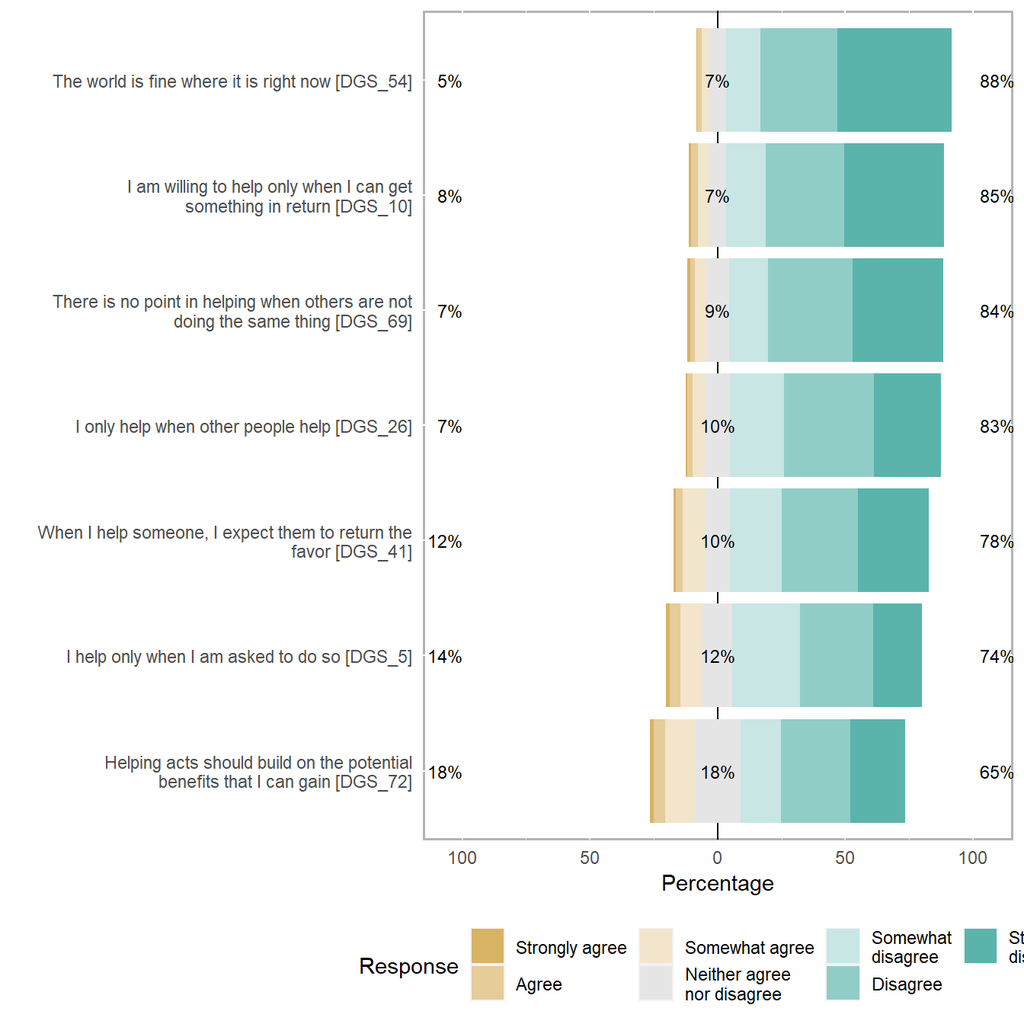

Likert plot of scale M6_2 items

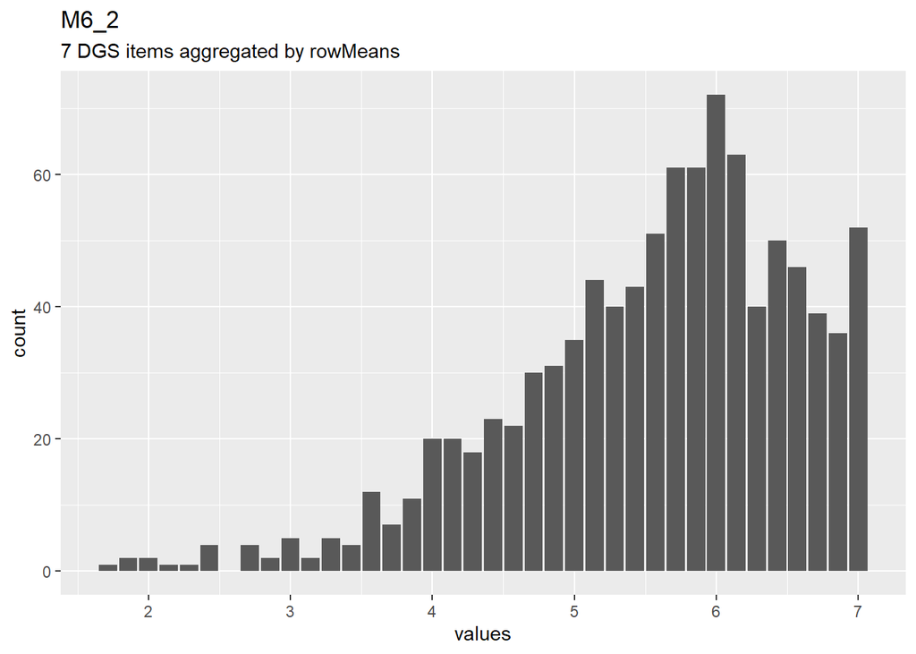

Distribution of scale M6_2

#### Reliability details

#### Summary statistics

| name | label | data_type | value_labels | n_missing | complete_rate | min | median | max | mean | sd | n_value_labels | hist |
| --- | --- | --- | --- | --- | --- | --- | --- | --- | --- | --- | --- | --- |
| DGS_5 | I help only when I am asked to do so | haven_labelled | 7. Strongly disagree, 6. Disagree, 5. Somewhat disagree, 4. Neither agree nor disagree, 3. Somewhat agree, 2. Agree, 1. Strongly agree | 0 | 1 | 1 | 5 | 7 | 5.194792 | 1.434919 | 7 | ▁▁▂▃▁▇▇▅ |
| DGS_10 | I am willing to help only when I can get something in return | haven_labelled | 7. Strongly disagree, 6. Disagree, 5. Somewhat disagree, 4. Neither agree nor disagree, 3. Somewhat agree, 2. Agree, 1. Strongly agree | 0 | 1 | 1 | 6 | 7 | 5.823958 | 1.345928 | 7 | ▁▁▁▂▁▃▆▇ |
| DGS_26 | I only help when other people help | haven_labelled | 7. Strongly disagree, 6. Disagree, 5. Somewhat disagree, 4. Neither agree nor disagree, 3. Somewhat agree, 2. Agree, 1. Strongly agree | 0 | 1 | 1 | 6 | 7 | 5.598958 | 1.268286 | 7 | ▁▁▁▂▁▅▇▆ |
| DGS_41 | When I help someone, I expect them to return the favor | haven_labelled | 7. Strongly disagree, 6. Disagree, 5. Somewhat disagree, 4. Neither agree nor disagree, 3. Somewhat agree, 2. Agree, 1. Strongly agree | 0 | 1 | 1 | 6 | 7 | 5.457292 | 1.434074 | 7 | ▁▁▂▂▁▆▇▇ |
| DGS_54 | The world is fine where it is right now | haven_labelled | 7. Strongly disagree, 6. Disagree, 5. Somewhat disagree, 4. Neither agree nor disagree, 3. Somewhat agree, 2. Agree, 1. Strongly agree | 0 | 1 | 1 | 6 | 7 | 5.997917 | 1.227932 | 7 | ▁▁▁▁▁▂▆▇ |
| DGS_69 | There is no point in helping when others are not doing the same thing | haven_labelled | 7. Strongly disagree, 6. Disagree, 5. Somewhat disagree, 4. Neither agree nor disagree, 3. Somewhat agree, 2. Agree, 1. Strongly agree | 0 | 1 | 1 | 6 | 7 | 5.766667 | 1.322672 | 7 | ▁▁▁▂▁▃▇▇ |
| DGS_72 | Helping acts should build on the potential benefits that I can gain | haven_labelled | 7. Strongly disagree, 6. Disagree, 5. Somewhat disagree, 4. Neither agree nor disagree, 3. Somewhat agree, 2. Agree, 1. Strongly agree | 0 | 1 | 1 | 5 | 7 | 5.100000 | 1.550135 | 7 | ▁▁▃▅▁▅▇▆ |

### Scale: M6_3

#### Overview

**Reliability**: Not computed.

**Missing**: 0.

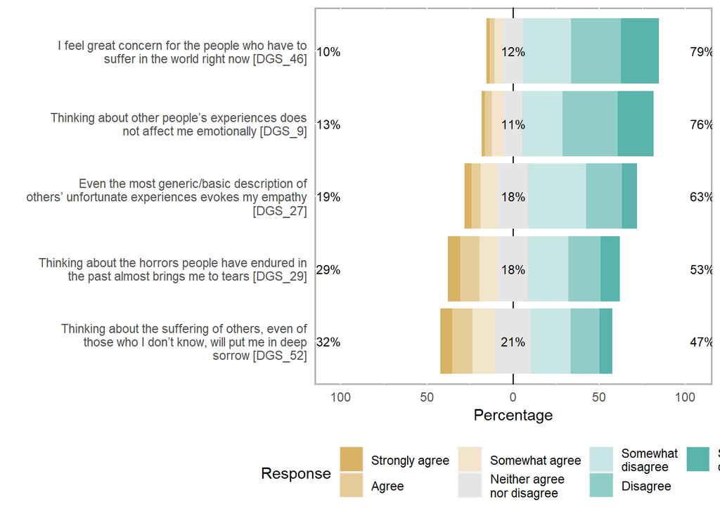

Likert plot of scale M6_3 items

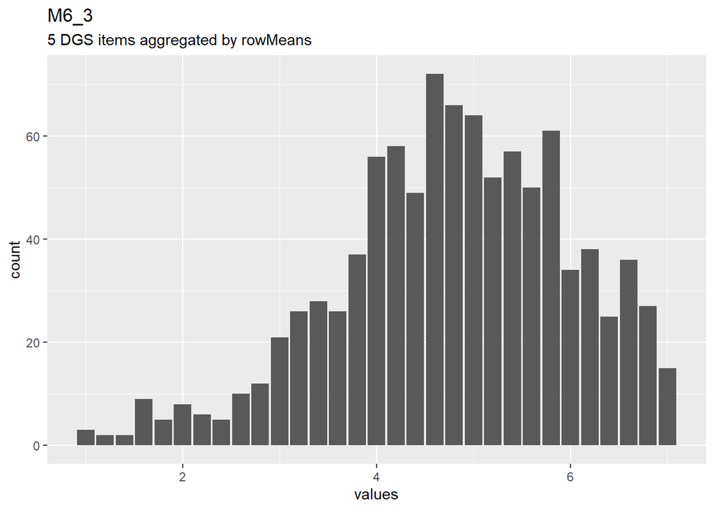

Distribution of scale M6_3

#### Reliability details

#### Summary statistics

| name | label | data_type | value_labels | n_missing | complete_rate | min | median | max | mean | sd | n_value_labels | hist |
| --- | --- | --- | --- | --- | --- | --- | --- | --- | --- | --- | --- | --- |
| DGS_9 | Thinking about other people’s experiences does not affect me emotionally | haven_labelled | 7. Strongly disagree, 6. Disagree, 5. Somewhat disagree, 4. Neither agree nor disagree, 3. Somewhat agree, 2. Agree, 1. Strongly agree | 0 | 1 | 1 | 6 | 7 | 5.288542 | 1.466012 | 7 | ▁▁▂▃▁▆▇▅ |
| DGS_27 | Even the most generic/basic description of others’ unfortunate experiences evokes my empathy | haven_labelled | 1. Strongly disagree, 2. Disagree, 3. Somewhat disagree, 4. Neither agree nor disagree, 5. Somewhat agree, 6. Agree, 7. Strongly agree | 0 | 1 | 1 | 5 | 7 | 4.685417 | 1.466695 | 7 | ▁▁▂▅▁▇▅▂ |
| DGS_29 | Thinking about the horrors people have endured in the past almost brings me to tears | haven_labelled | 1. Strongly disagree, 2. Disagree, 3. Somewhat disagree, 4. Neither agree nor disagree, 5. Somewhat agree, 6. Agree, 7. Strongly agree | 0 | 1 | 1 | 5 | 7 | 4.391667 | 1.740978 | 7 | ▂▃▃▆▁▇▆▃ |
| DGS_46 | I feel great concern for the people who have to suffer in the world right now | haven_labelled | 1. Strongly disagree, 2. Disagree, 3. Somewhat disagree, 4. Neither agree nor disagree, 5. Somewhat agree, 6. Agree, 7. Strongly agree | 0 | 1 | 1 | 6 | 7 | 5.356250 | 1.376157 | 7 | ▁▁▂▃▁▇▇▆ |
| DGS_52 | Thinking about the suffering of others, even of those who I don’t know, will put me in deep sorrow | haven_labelled | 1. Strongly disagree, 2. Disagree, 3. Somewhat disagree, 4. Neither agree nor disagree, 5. Somewhat agree, 6. Agree, 7. Strongly agree | 0 | 1 | 1 | 4 | 7 | 4.220833 | 1.659549 | 7 | ▂▅▅▇▁▇▆▂ |

### Scale: M6_4

#### Overview

**Reliability**: Not computed.

**Missing**: 0.

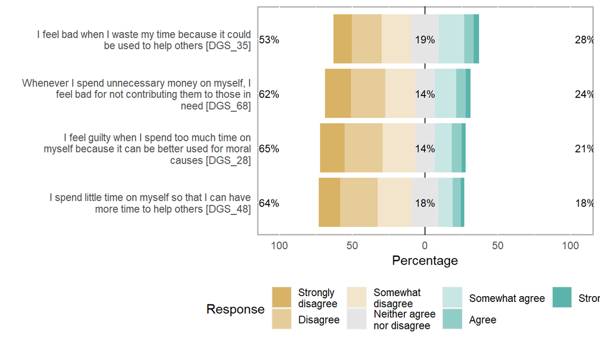

Likert plot of scale M6_4 items

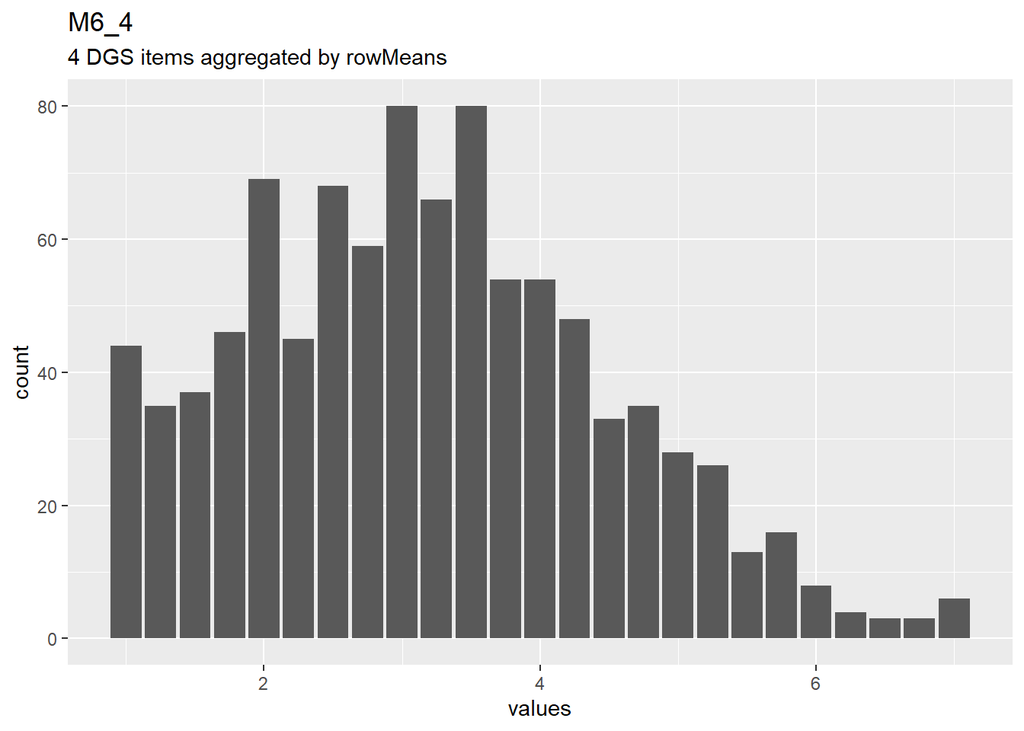

Distribution of scale M6_4

#### Reliability details

#### Summary statistics

| name | label | data_type | value_labels | n_missing | complete_rate | min | median | max | mean | sd | n_value_labels | hist |
| --- | --- | --- | --- | --- | --- | --- | --- | --- | --- | --- | --- | --- |
| DGS_28 | I feel guilty when I spend too much time on myself because it can be better used for moral causes | haven_labelled | 1. Strongly disagree, 2. Disagree, 3. Somewhat disagree, 4. Neither agree nor disagree, 5. Somewhat agree, 6. Agree, 7. Strongly agree | 0 | 1 | 1 | 3 | 7 | 3.078125 | 1.605887 | 7 | ▅▇▇▅▁▃▂▁ |
| DGS_35 | I feel bad when I waste my time because it could be used to help others | haven_labelled | 1. Strongly disagree, 2. Disagree, 3. Somewhat disagree, 4. Neither agree nor disagree, 5. Somewhat agree, 6. Agree, 7. Strongly agree | 0 | 1 | 1 | 3 | 7 | 3.427083 | 1.609052 | 7 | ▅▇▇▇▁▇▂▂ |
| DGS_48 | I spend little time on myself so that I can have more time to help others | haven_labelled | 1. Strongly disagree, 2. Disagree, 3. Somewhat disagree, 4. Neither agree nor disagree, 5. Somewhat agree, 6. Agree, 7. Strongly agree | 0 | 1 | 1 | 3 | 7 | 3.092708 | 1.516936 | 7 | ▅▇▇▆▁▃▂▁ |
| DGS_68 | Whenever I spend unnecessary money on myself, I feel bad for not contributing them to those in need | haven_labelled | 1. Strongly disagree, 2. Disagree, 3. Somewhat disagree, 4. Neither agree nor disagree, 5. Somewhat agree, 6. Agree, 7. Strongly agree | 0 | 1 | 1 | 3 | 7 | 3.159375 | 1.659370 | 7 | ▆▇▇▅▁▅▂▁ |

### Scale: M6_5

#### Overview

**Reliability**: Not computed.

**Missing**: 0.

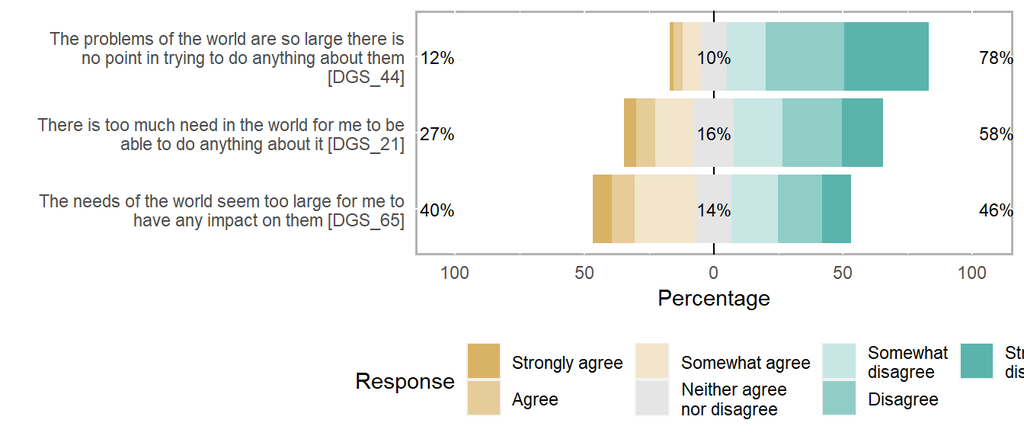

Likert plot of scale M6_5 items

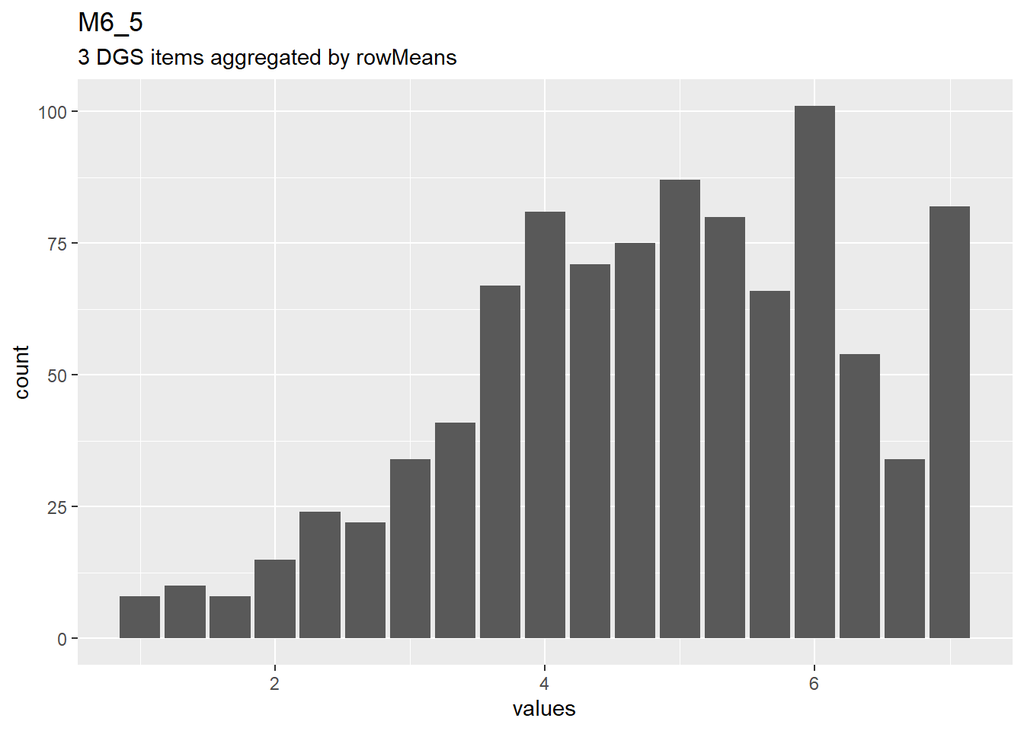

Distribution of scale M6_5

#### Reliability details

#### Summary statistics

| name | label | data_type | value_labels | n_missing | complete_rate | min | median | max | mean | sd | n_value_labels | hist |
| --- | --- | --- | --- | --- | --- | --- | --- | --- | --- | --- | --- | --- |
| DGS_21 | There is too much need in the world for me to be able to do anything about it | haven_labelled | 7. Strongly disagree, 6. Disagree, 5. Somewhat disagree, 4. Neither agree nor disagree, 3. Somewhat agree, 2. Agree, 1. Strongly agree | 0 | 1 | 1 | 5 | 7 | 4.691667 | 1.707108 | 7 | ▂▂▅▆▁▆▇▆ |
| DGS_44 | The problems of the world are so large there is no point in trying to do anything about them | haven_labelled | 7. Strongly disagree, 6. Disagree, 5. Somewhat disagree, 4. Neither agree nor disagree, 3. Somewhat agree, 2. Agree, 1. Strongly agree | 0 | 1 | 1 | 6 | 7 | 5.557292 | 1.490620 | 7 | ▁▁▂▂▁▃▇▇ |
| DGS_65 | The needs of the world seem too large for me to have any impact on them | haven_labelled | 7. Strongly disagree, 6. Disagree, 5. Somewhat disagree, 4. Neither agree nor disagree, 3. Somewhat agree, 2. Agree, 1. Strongly agree | 0 | 1 | 1 | 4 | 7 | 4.218750 | 1.758063 | 7 | ▂▃▇▅▁▆▆▃ |

### Scale: M6_6

#### Overview

**Reliability**: Not computed.

**Missing**: 0.

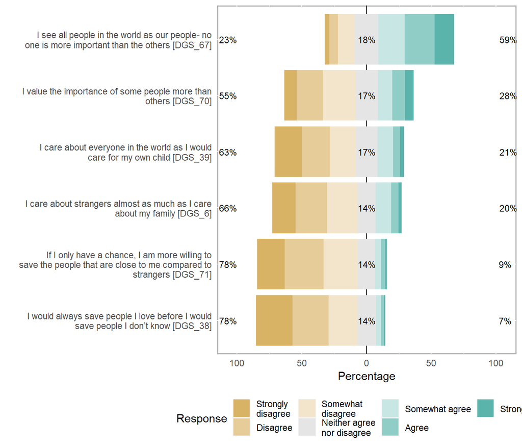

Likert plot of scale M6_6 items

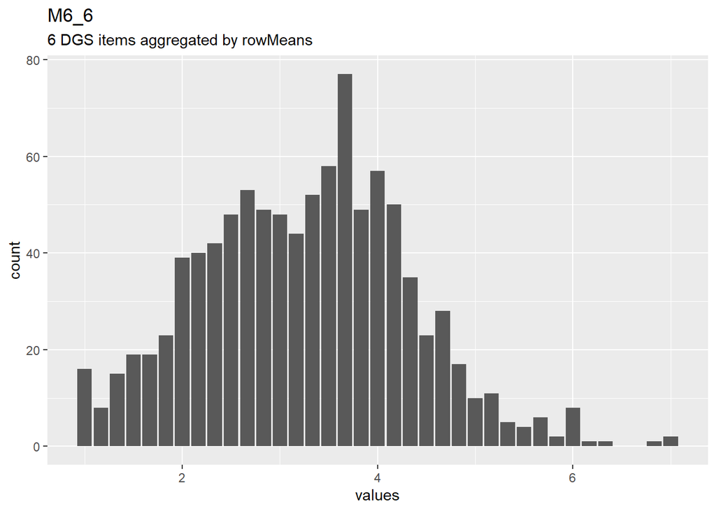

Distribution of scale M6_6

#### Reliability details

#### Summary statistics

| name | label | data_type | value_labels | n_missing | complete_rate | min | median | max | mean | sd | n_value_labels | hist |
| --- | --- | --- | --- | --- | --- | --- | --- | --- | --- | --- | --- | --- |
| DGS_6 | I care about strangers almost as much as I care about my family | haven_labelled | 1. Strongly disagree, 2. Disagree, 3. Somewhat disagree, 4. Neither agree nor disagree, 5. Somewhat agree, 6. Agree, 7. Strongly agree | 0 | 1 | 1 | 3 | 7 | 3.043750 | 1.578057 | 7 | ▆▇▇▅▁▃▂▁ |
| DGS_38 | I would always save people I love before I would save people I don’t know | haven_labelled | 7. Strongly disagree, 6. Disagree, 5. Somewhat disagree, 4. Neither agree nor disagree, 3. Somewhat agree, 2. Agree, 1. Strongly agree | 0 | 1 | 1 | 2 | 7 | 2.491667 | 1.347741 | 7 | ▇▇▆▅▁▁▁▁ |
| DGS_39 | I care about everyone in the world as I would care for my own child | haven_labelled | 1. Strongly disagree, 2. Disagree, 3. Somewhat disagree, 4. Neither agree nor disagree, 5. Somewhat agree, 6. Agree, 7. Strongly agree | 0 | 1 | 1 | 3 | 7 | 3.054167 | 1.640590 | 7 | ▇▇▇▆▁▅▂▁ |
| DGS_67 | I see all people in the world as our people- no one is more important than the others | haven_labelled | 1. Strongly disagree, 2. Disagree, 3. Somewhat disagree, 4. Neither agree nor disagree, 5. Somewhat agree, 6. Agree, 7. Strongly agree | 0 | 1 | 1 | 5 | 7 | 4.747917 | 1.629049 | 7 | ▁▂▅▆▁▇▇▅ |
| DGS_70 | I value the importance of some people more than others | haven_labelled | 7. Strongly disagree, 6. Disagree, 5. Somewhat disagree, 4. Neither agree nor disagree, 3. Somewhat agree, 2. Agree, 1. Strongly agree | 0 | 1 | 1 | 3 | 7 | 3.565625 | 1.687180 | 7 | ▃▆▇▆▁▃▃▂ |
| DGS_71 | If I only have a chance, I am more willing to save the people that are close to me compared to strangers | haven_labelled | 7. Strongly disagree, 6. Disagree, 5. Somewhat disagree, 4. Neither agree nor disagree, 3. Somewhat agree, 2. Agree, 1. Strongly agree | 0 | 1 | 1 | 2 | 7 | 2.641667 | 1.341071 | 7 | ▆▇▇▃▁▁▁▁ |

### Scale: Organization

#### Overview

**Missing**: 0.

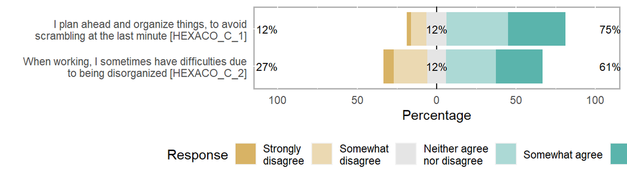

Likert plot of scale Organization items

[figure not shown]

Distribution of scale Organization

#### Reliability details

```
## No viewer found, probably documenting or testing
```

##### Scale diagnosis

###### Reliability (internal consistency) estimates

##### Scale structure

###### Information about this scale

| Dataframe: | res$dat |
| --- | --- |
| Items: | HEXACO_C_1 & HEXACO_C_2 |
| Observations: | 960 |
| Positive correlations: | 1 |
| Number of correlations: | 1 |
| Percentage positive correlations: | 100 |

###### Estimates assuming interval level

###### Estimates for two-item measures

| Spearman Brown coefficient: | 0.59 |
| --- | --- |
| Coefficient Alpha: | 0.58 |
| Pearson Correlation: | 0.42 |

###### Eigen values

1.417 & 0.583

###### Item descriptives

|  | mean | median | var | sd | IQR | se | min | q1 | q3 | max | skew | kurt | dip | n | NA | valid |
| --- | --- | --- | --- | --- | --- | --- | --- | --- | --- | --- | --- | --- | --- | --- | --- | --- |
| HEXACO_C_1 | 3.9594 | 4 | 1.1214 | 1.059 | 1.5 | 0.0342 | 1 | 2.5 | 5 | 5 | -0.9643 | 0.235 | 0.1807 | 960 | 0 | 960 |
| HEXACO_C_2 | 3.5635 | 4 | 1.6414 | 1.2812 | 3 | 0.0413 | 1 | 2 | 5 | 5 | -0.483 | -1.0224 | 0.1469 | 960 | 0 | 960 |

###### Scattermatrix

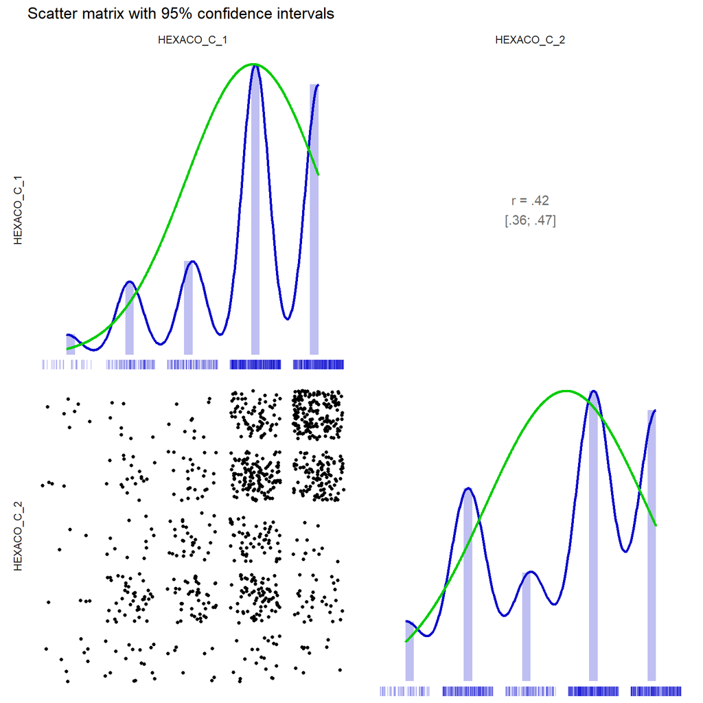

Scatterplot

```
## No viewer found, probably documenting or testing
```

#### Summary statistics

| name | label | data_type | value_labels | n_missing | complete_rate | min | median | max | mean | sd | n_value_labels | hist |
| --- | --- | --- | --- | --- | --- | --- | --- | --- | --- | --- | --- | --- |
| HEXACO_C_1 | I plan ahead and organize things, to avoid scrambling at the last minute | haven_labelled | 1. Strongly disagree, 2. Somewhat disagree, 3. Neither agree nor disagree, 4. Somewhat agree, 5. Strongly agree | 0 | 1 | 1 | 4 | 5 | 3.959375 | 1.058958 | 5 | ▁▂▁▂▁▇▁▇ |
| HEXACO_C_2 | When working, I sometimes have difficulties due to being disorganized | haven_labelled | 5. Strongly disagree, 4. Somewhat disagree, 3. Neither agree nor disagree, 2. Somewhat agree, 1. Strongly agree | 0 | 1 | 1 | 4 | 5 | 3.563542 | 1.281180 | 5 | ▂▅▁▃▁▇▁▇ |

### Scale: Diligence

#### Overview

**Missing**: 0.

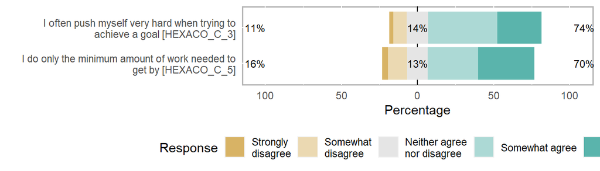

Likert plot of scale Diligence items

[figure not shown]

Distribution of scale Diligence

#### Reliability details

```
## No viewer found, probably documenting or testing
```

##### Scale diagnosis

###### Reliability (internal consistency) estimates

##### Scale structure

###### Information about this scale

| Dataframe: | res$dat |
| --- | --- |
| Items: | HEXACO_C_3 & HEXACO_C_5 |
| Observations: | 960 |
| Positive correlations: | 1 |
| Number of correlations: | 1 |
| Percentage positive correlations: | 100 |

###### Estimates assuming interval level

###### Estimates for two-item measures

| Spearman Brown coefficient: | 0.59 |
| --- | --- |
| Coefficient Alpha: | 0.58 |
| Pearson Correlation: | 0.42 |

###### Eigen values

1.416 & 0.584

###### Item descriptives

|  | mean | median | var | sd | IQR | se | min | q1 | q3 | max | skew | kurt | dip | n | NA | valid |
| --- | --- | --- | --- | --- | --- | --- | --- | --- | --- | --- | --- | --- | --- | --- | --- | --- |
| HEXACO_C_3 | 3.8927 | 4 | 1.0156 | 1.0078 | 2 | 0.0325 | 1 | 3 | 5 | 5 | -0.9355 | 0.4539 | 0.1453 | 960 | 0 | 960 |
| HEXACO_C_5 | 3.8708 | 4 | 1.3305 | 1.1535 | 2 | 0.0372 | 1 | 2 | 5 | 5 | -0.8207 | -0.3202 | 0.1651 | 960 | 0 | 960 |

###### Scattermatrix

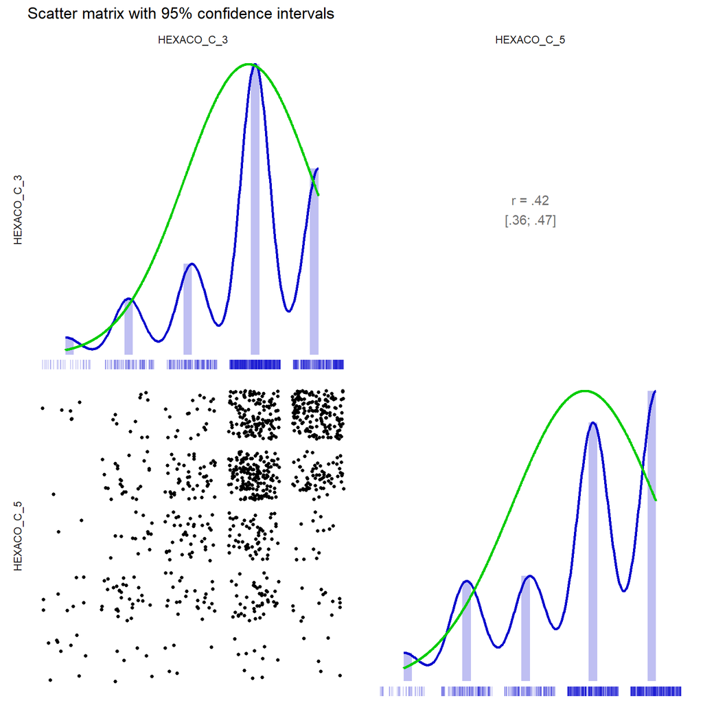

Scatterplot

```
## No viewer found, probably documenting or testing
```

#### Summary statistics

| name | label | data_type | value_labels | n_missing | complete_rate | min | median | max | mean | sd | n_value_labels | hist |
| --- | --- | --- | --- | --- | --- | --- | --- | --- | --- | --- | --- | --- |
| HEXACO_C_3 | I often push myself very hard when trying to achieve a goal | haven_labelled | 1. Strongly disagree, 2. Somewhat disagree, 3. Neither agree nor disagree, 4. Somewhat agree, 5. Strongly agree | 0 | 1 | 1 | 4 | 5 | 3.892708 | 1.007764 | 5 | ▁▂▁▂▁▇▁▅ |
| HEXACO_C_5 | I do only the minimum amount of work needed to get by | haven_labelled | 5. Strongly disagree, 4. Somewhat disagree, 3. Neither agree nor disagree, 2. Somewhat agree, 1. Strongly agree | 0 | 1 | 1 | 4 | 5 | 3.870833 | 1.153488 | 5 | ▁▃▁▃▁▇▁▇ |

### Scale: Perfectionism

#### Overview

**Reliability**: Not computed.

**Missing**: 0.

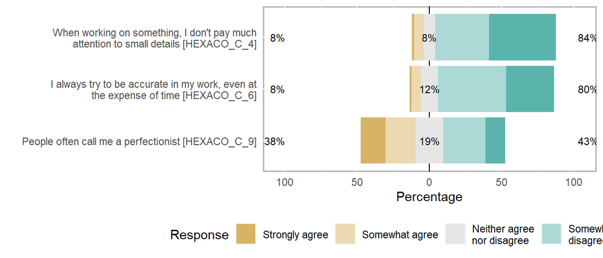

Likert plot of scale Perfectionism items

[figure not shown]

Distribution of scale Perfectionism

#### Reliability details

#### Summary statistics

| name | label | data_type | value_labels | n_missing | complete_rate | min | median | max | mean | sd | n_value_labels | hist |
| --- | --- | --- | --- | --- | --- | --- | --- | --- | --- | --- | --- | --- |
| HEXACO_C_4 | When working on something, I don’t pay much attention to small details | haven_labelled | 5. Strongly disagree, 4. Somewhat disagree, 3. Neither agree nor disagree, 2. Somewhat agree, 1. Strongly agree | 0 | 1 | 1 | 4 | 5 | 4.201042 | 0.9591223 | 5 | ▁▁▁▂▁▆▁▇ |
| HEXACO_C_6 | I always try to be accurate in my work, even at the expense of time | haven_labelled | 1. Strongly disagree, 2. Somewhat disagree, 3. Neither agree nor disagree, 4. Somewhat agree, 5. Strongly agree | 0 | 1 | 1 | 4 | 5 | 4.051042 | 0.9009895 | 5 | ▁▁▁▂▁▇▁▆ |
| HEXACO_C_9 | People often call me a perfectionist | haven_labelled | 1. Strongly disagree, 2. Somewhat disagree, 3. Neither agree nor disagree, 4. Somewhat agree, 5. Strongly agree | 0 | 1 | 1 | 3 | 5 | 3.014583 | 1.3171666 | 5 | ▅▆▁▅▁▇▁▃ |

### Scale: Prudence

#### Overview

**Reliability**: Not computed.

**Missing**: 0.

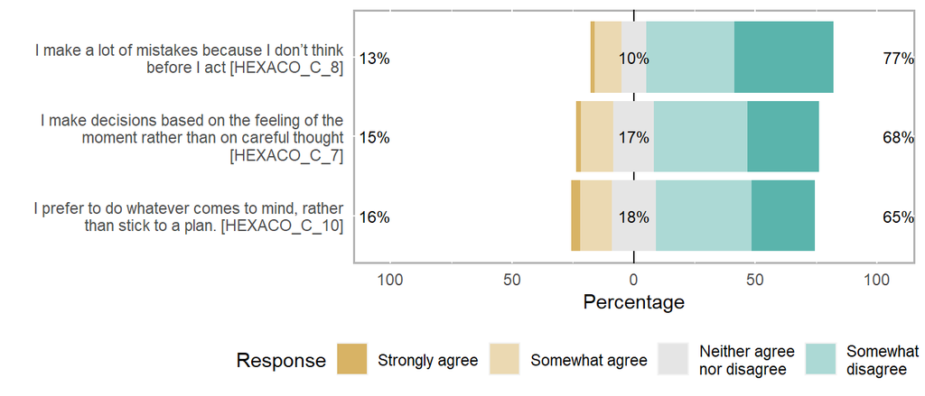

Likert plot of scale Prudence items

[figure not shown]

Distribution of scale Prudence

#### Reliability details

#### Summary statistics

| name | label | data_type | value_labels | n_missing | complete_rate | min | median | max | mean | sd | n_value_labels | hist |
| --- | --- | --- | --- | --- | --- | --- | --- | --- | --- | --- | --- | --- |
| HEXACO_C_7 | I make decisions based on the feeling of the moment rather than on careful thought | haven_labelled | 5. Strongly disagree, 4. Somewhat disagree, 3. Neither agree nor disagree, 2. Somewhat agree, 1. Strongly agree | 0 | 1 | 1 | 4 | 5 | 3.798958 | 1.067190 | 5 | ▁▃▁▃▁▇▁▆ |
| HEXACO_C_8 | I make a lot of mistakes because I don’t think before I act | haven_labelled | 5. Strongly disagree, 4. Somewhat disagree, 3. Neither agree nor disagree, 2. Somewhat agree, 1. Strongly agree | 0 | 1 | 1 | 4 | 5 | 4.034375 | 1.052266 | 5 | ▁▂▁▂▁▇▁▇ |
| HEXACO_C_10 | I prefer to do whatever comes to mind, rather than stick to a plan. | haven_labelled | 5. Strongly disagree, 4. Somewhat disagree, 3. Neither agree nor disagree, 2. Somewhat agree, 1. Strongly agree | 0 | 1 | 1 | 4 | 5 | 3.711458 | 1.095576 | 5 | ▁▂▁▃▁▇▁▅ |